Cl<sub>1,3</sub> Julian L. Avila-Martinez

High-Energy Physics Data Mining & Machine Learning · Python · scikit-learn · Pandas

# LHC High-Energy Particle Collision Classification Across 11 ML Architectures

Comparative Benchmark of MLP Neural Networks (90.3% Accuracy), Random Forests, SVMs, KNN & Decision Trees

**Author:** Julian L. Avila-Martinez **Affiliation:** Universidad Distrital Francisco José de Caldas **Format:** Quarto Published Notebook & Code

## 📓 Notebook 1: Multi-Model Classification Benchmark (classification-methods-comparison.ipynb)

⬇ Download Raw .ipynb

In [1]:PYTHON

```
import pandas as pd
import matplotlib.pyplot as plt
```

In [2]:PYTHON

```
columnas = ["sepal length","sepal width","petal length","petal width","class"]

df = pd.read_csv("Dataset/iris.data", header=None, names=columnas)
```

In [3]:PYTHON

```
df.head()
```

|  | sepal length | sepal width | petal length | petal width | class |
| --- | --- | --- | --- | --- | --- |
| 0 | 5.1 | 3.5 | 1.4 | 0.2 | Iris-setosa |
| 1 | 4.9 | 3.0 | 1.4 | 0.2 | Iris-setosa |
| 2 | 4.7 | 3.2 | 1.3 | 0.2 | Iris-setosa |
| 3 | 4.6 | 3.1 | 1.5 | 0.2 | Iris-setosa |
| 4 | 5.0 | 3.6 | 1.4 | 0.2 | Iris-setosa |

## Implementación de métodos:

### Logistic Regresion:

In [4]:PYTHON

```
# importamos librerias, LogisticRegression para el metodo, train_test_split para hacer la division
# de los datos y las métricas
from sklearn.linear_model import LogisticRegression
from sklearn.model_selection import train_test_split
from sklearn.metrics import accuracy_score, confusion_matrix, classification_report


# dividimos entre las caracteristicas y las clases
X = df.drop('class', axis=1)
y = df['class']

# se hace la partición del df
X_train, X_test, y_train, y_test = train_test_split(X, y, test_size=0.3, random_state=42)

model = LogisticRegression(max_iter=200)

# se entrena el modelo
model.fit(X_train, y_train)

# se predicen los datos de testeo
y_pred = model.predict(X_test)

#métricas
accuracy = accuracy_score(y_test, y_pred)
conf_matrix = confusion_matrix(y_test, y_pred)
class_report = classification_report(y_test, y_pred)

print(f'Accuracy: {accuracy * 100:.2f}%')
print('\nMatriz de confusión:')
print(conf_matrix)
print('\nReporte de clasificación:')
print(class_report)
```

```
Accuracy: 100.00%

Matriz de confusión:
[[19  0  0]
 [ 0 13  0]
 [ 0  0 13]]

Reporte de clasificación:
                 precision    recall  f1-score   support

    Iris-setosa       1.00      1.00      1.00        19
Iris-versicolor       1.00      1.00      1.00        13
 Iris-virginica       1.00      1.00      1.00        13

       accuracy                           1.00        45
      macro avg       1.00      1.00      1.00        45
   weighted avg       1.00      1.00      1.00        45
```

### SVM:

In [5]:PYTHON

```
from sklearn.svm import SVC

X_train, X_test, y_train, y_test = train_test_split(X, y, test_size=0.3, random_state=42)

svm_model = SVC(kernel='linear')

svm_model.fit(X_train, y_train)

y_pred = svm_model.predict(X_test)

accuracy = accuracy_score(y_test, y_pred)
conf_matrix = confusion_matrix(y_test, y_pred)
class_report = classification_report(y_test, y_pred)

print(f'Accuracy: {accuracy * 100:.2f}%')
print('\nMatriz de confusión:')
print(conf_matrix)
print('\nReporte de clasificación:')
print(class_report)
```

```
Accuracy: 100.00%

Matriz de confusión:
[[19  0  0]
 [ 0 13  0]
 [ 0  0 13]]

Reporte de clasificación:
                 precision    recall  f1-score   support

    Iris-setosa       1.00      1.00      1.00        19
Iris-versicolor       1.00      1.00      1.00        13
 Iris-virginica       1.00      1.00      1.00        13

       accuracy                           1.00        45
      macro avg       1.00      1.00      1.00        45
   weighted avg       1.00      1.00      1.00        45
```

### Decision Tree:

In [6]:PYTHON

```
from sklearn.tree import DecisionTreeClassifier, plot_tree

X_train, X_test, y_train, y_test = train_test_split(X, y, test_size=0.3, random_state=42)

tree_model = DecisionTreeClassifier(criterion="entropy", max_depth=2, random_state=42)

tree_model.fit(X_train, y_train)

y_pred = tree_model.predict(X_test)

conf_matrix = confusion_matrix(y_test, y_pred)
```

In [7]:PYTHON

```
plt.figure(figsize=(12, 8))
plot_tree(tree_model, filled=True, feature_names=X.columns, class_names=y.unique(), rounded=True, proportion=False)
plt.title("Árbol de Decisión", fontsize=16)
plt.show()
```

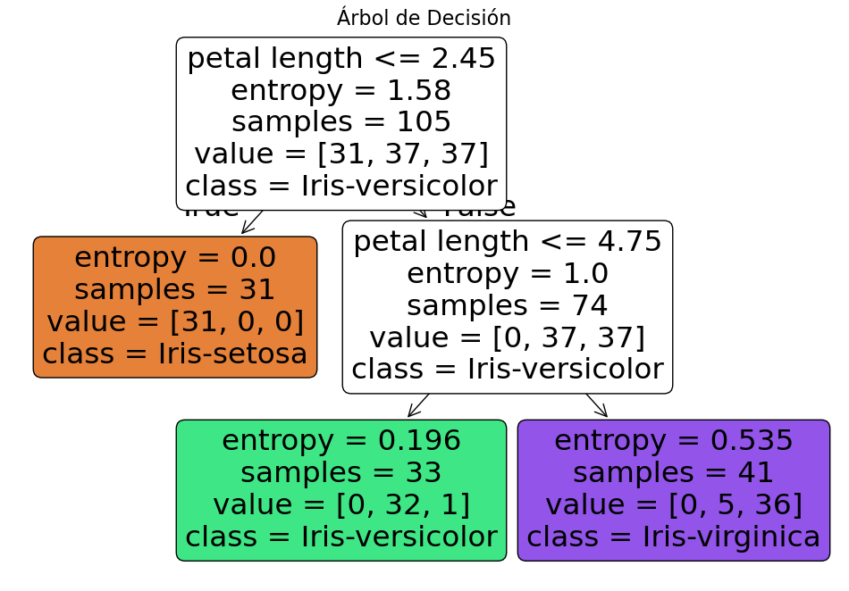

In [8]:PYTHON

```
from sklearn.metrics import classification_report
from sklearn.metrics import accuracy_score

accuracy = accuracy_score(y_test, y_pred)
print(f"Precisión: {accuracy:.2f}")
report = classification_report(y_test, y_pred, target_names=y.unique())
print(report)
```

```
Precisión: 0.98
                 precision    recall  f1-score   support

    Iris-setosa       1.00      1.00      1.00        19
Iris-versicolor       1.00      0.92      0.96        13
 Iris-virginica       0.93      1.00      0.96        13

       accuracy                           0.98        45
      macro avg       0.98      0.97      0.97        45
   weighted avg       0.98      0.98      0.98        45
```

## Hyperparámetros:

### 1. Logistic Regresion:

#### 1.1. C: (inversa de la regularización). (Por defecto: '1.0')

#### Descripción:

Controla la regularización L2 en el modelo. Un valor alto de C significa menos regularización (el modelo se ajustará más a los datos), mientras que un valor bajo de C significa más regularización (el modelo será más simple y generalizará mejor).

In [9]:PYTHON

```
model = LogisticRegression(C=1.0)
```

#### 1.2. solver: Método de optimización. (Por defecto: 'lbfgs')

#### Descripción:

Especifica el algoritmo utilizado para optimizar la función de coste de la regresión logística.

#### Opciones comunes:

- 'liblinear': Un algoritmo eficiente para pequeños conjuntos de datos y modelos binarios.
- 'newton-cg': Utiliza el método de Newton para optimizar, bueno para problemas más grandes y multiclasificación.
- 'lbfgs': Un optimizador quasi-Newton que funciona bien para problemas más grandes.
- 'saga': Algoritmo de optimización que también es eficiente con grandes datasets y permite la regularización elastic net.

In [10]:PYTHON

```
model = LogisticRegression(solver='lbfgs')
```

#### 1.3. penalty: Tipo de regularización. (Por defecto: 'l2')

#### Descripción:

Tipo de regularización utilizada en la regresión logística. En general, los dos tipos más comunes son:

- L2: Regularización de Ridge, que es la más común y la que se usa por defecto.
- L1: Regularización de Lasso, que puede inducir una sparsidad (es decir, hacer que algunos coeficientes del modelo sean cero).
- elasticnet: Combinación de L1 y L2, útil cuando se desea un equilibrio entre ambos.

In [11]:PYTHON

```
model = LogisticRegression(penalty='l2')
```

#### 1.4. max_iter: Número máximo de iteraciones para la optimización. (Por defecto: 100)

#### Descripción:

Número máximo de iteraciones que el algoritmo puede realizar durante la optimización.

In [12]:PYTHON

```
model = LogisticRegression(max_iter=100)
```

#### 1.5. tol: determina la precisión de la convergencia en el proceso de optimización. (Por defecto: 1e-4)

#### Descripción:

Determina la tolerancia para la convergencia del optimizador. Si la mejora entre iteraciones sucesivas es menor que esta tolerancia, el algoritmo se detiene.

In [13]:PYTHON

```
model = LogisticRegression(tol=1e-4)
```

### 2. SVM:

#### 2.1. C: (parametro de penalización) Controla el margen y los errores. (Por defecto: C=1.0)

#### Descripción:

Similar al de la regresión logística, C es un parámetro que controla el equilibrio entre el margen máximo (generalización) y los errores de clasificación en el conjunto de entrenamiento.

In [14]:PYTHON

```
model = SVC(C=1.0)
```

#### 2.2. kernel: Funcion nucleo (Por defecto: 'rbf')

#### Descripción:

Define el tipo de función de núcleo que se usa para transformar los datos en un espacio de características de mayor dimensión, donde se pueden encontrar los márgenes óptimos.

##### tipos de kernel:

- 'linear': El núcleo lineal es adecuado para problemas donde las clases son separables de manera lineal.
- 'poly': El núcleo polinómico se usa cuando las clases no son lineales pero pueden separarse mediante un polinomio.
- 'rbf' (Radial Basis Function): Es el núcleo más común, utilizado cuando las clases son no lineales y separables mediante una función gaussiana.
- 'sigmoid': Menos común, utilizado para problemas no lineales con una frontera de decisión sigmoidea.

In [15]:PYTHON

```
model = SVC(kernel='rbf')
```

#### 2.3. gamma: Parámetro del núcleo. (Por defecto: 'scale')

#### Descripción:

El parámetro gamma controla el alcance de la influencia de un solo punto de datos sobre la clasificación.

In [16]:PYTHON

```
model = SVC(gamma='scale')
```

#### 2.4. degree: Grado del polinomio para el kernel 'poly'. (Por defecto: degree=3)

#### Descripción:

Este parámetro es relevante solo cuando se usa el núcleo polinómico ('poly'). Especifica el grado del polinomio utilizado para mapear los datos al espacio de características.

In [17]:PYTHON

```
model = SVC(kernel='poly', degree=3)
```

#### 2.5. shrinking: Usar heurística de "shrinking". (Por defecto: shrinking=True)

#### Descripción:

Este parámetro indica si se debe utilizar la heurística de "shrinking" durante la optimización del SVM.

- 'True': Aplica la heurística de "shrinking", lo que puede hacer que el algoritmo converja más rápido al eliminar ciertos puntos durante el entrenamiento.
- 'False': No se aplica la heurística de "shrinking", lo que puede hacer el proceso más lento pero más exhaustivo.

In [18]:PYTHON

```
model = SVC(shrinking=True)
```

### 3. Decision Tree:

#### 3.1. max_depth: Profundidad máxima del árbol. (Por defecto: max_depth=None)

#### Descripción:

Este parámetro controla la profundidad máxima del árbol de decisión, es decir, cuántos niveles de nodos puede tener el árbol.

- Un valor alto de max_depth permite que el árbol crezca más y capture patrones más complejos, lo que puede llevar a sobreajuste si es demasiado alto.
- Un valor bajo de max_depth limita el crecimiento del árbol y hace que el modelo sea más general y menos propenso a sobreajustar.

#### Valor por defecto:

max_depth=None (lo que significa que el árbol se expandirá hasta que cada hoja contenga menos de min_samples_split muestras).

In [25]:PYTHON

```
model = DecisionTreeClassifier(max_depth=5)
```

#### 3.2. min_samples_split: Número mínimo de muestras requeridas para dividir un nodo. (Por defecto: min_samples_split=2)

#### Descripción:

Especifica el número mínimo de muestras requeridas para dividir un nodo interno.

- Un valor bajo de min_samples_split permitirá que el árbol se divida en nodos más pequeños, lo que puede llevar a sobreajuste.
- Un valor alto de min_samples_split hará que el árbol no divida los nodos a menos que haya un número suficiente de muestras, lo que hace que el modelo sea más generalizable.

In [24]:PYTHON

```
model = DecisionTreeClassifier(min_samples_split=10)
```

#### 3.3. min_samples_leaf: Número mínimo de muestras en una hoja. (Por defecto: min_samples_leaf=1)

#### Descripción:

Controla el número mínimo de muestras que debe tener una hoja para considerarse válida. - Un valor bajo de min_samples_leaf puede generar muchas hojas pequeñas, lo que puede llevar a sobreajuste. - Un valor alto hace que las hojas contengan más muestras y, por lo tanto, puede reducir el sobreajuste.

In [23]:PYTHON

```
model = DecisionTreeClassifier(min_samples_leaf=1)
```

#### 3.4. max_features: Número máximo de características a considerar en cada división. (Por defecto: max_features=None)

#### Descripción:

Especifica el número máximo de características que se deben considerar al buscar la mejor división para un nodo.

- Si se ajusta a un valor pequeño, reduces la complejidad del modelo y puedes ayudar a evitar el sobreajuste, pero también puede reducir la precisión.
- Si se establece como 'auto' o 'sqrt', utiliza la raíz cuadrada del número total de características. 'log2' usa el logaritmo en base 2 del número de características.

In [22]:PYTHON

```
model = DecisionTreeClassifier(max_features='None')
```

#### 3.5. criterion: Función de calidad de la división. (Por defecto: criterion='gini')

#### Descripción:

Controla la función de evaluación utilizada para medir la calidad de las divisiones en el árbol.

- 'gini': Usa el índice de Gini, que mide la pureza de las divisiones. Es el valor por defecto.
- 'entropy': Usa la entropía, que mide la incertidumbre o la impureza de las divisiones.

In [20]:PYTHON

```
model = DecisionTreeClassifier(criterion='gini')
```

## 📓 Notebook 2: K-Nearest Neighbors Hyperparameter Analysis (knn-classification.ipynb)

⬇ Download Raw .ipynb

In [33]:PYTHON

```
import numpy as np
from sklearn.datasets import load_iris
from sklearn.model_selection import train_test_split
from sklearn.preprocessing import StandardScaler
from sklearn.neighbors import KNeighborsClassifier
from sklearn.metrics import accuracy_score, classification_report, confusion_matrix
```

In [34]:PYTHON

```
iris = load_iris()
X, y = iris.data, iris.target
X_train, X_test, y_train, y_test = train_test_split(X, y, test_size=0.2, random_state=42)
```

In [35]:PYTHON

[output not shown]

In [36]:PYTHON

```
def evaluate_knn(k_values):
  return [
    (
      k,
      accuracy_score(y_train, KNeighborsClassifier(n_neighbors=k).fit(X_train, y_train).predict(X_train)),
      accuracy_score(y_test, KNeighborsClassifier(n_neighbors=k).fit(X_train, y_train).predict(X_test)),
      abs(
        accuracy_score(y_train, KNeighborsClassifier(n_neighbors=k).fit(X_train, y_train).predict(X_train)) -
        accuracy_score(y_test, KNeighborsClassifier(n_neighbors=k).fit(X_train, y_train).predict(X_test))
      )
    )
    for k in k_values
  ]
```

In [37]:PYTHON

```
results = evaluate_knn(range(1, 21))
for k, train_acc, test_acc, diff in results:
  print(f"k={k}, Train Acc={train_acc:.4f}, Test Acc={test_acc:.4f}, Diff={diff:.4f}")
```

```
k=1, Train Acc=1.0000, Test Acc=1.0000, Diff=0.0000
k=2, Train Acc=0.9667, Test Acc=1.0000, Diff=0.0333
k=3, Train Acc=0.9417, Test Acc=1.0000, Diff=0.0583
k=4, Train Acc=0.9583, Test Acc=1.0000, Diff=0.0417
k=5, Train Acc=0.9583, Test Acc=1.0000, Diff=0.0417
k=6, Train Acc=0.9583, Test Acc=1.0000, Diff=0.0417
k=7, Train Acc=0.9583, Test Acc=1.0000, Diff=0.0417
k=8, Train Acc=0.9583, Test Acc=1.0000, Diff=0.0417
k=9, Train Acc=0.9500, Test Acc=1.0000, Diff=0.0500
k=10, Train Acc=0.9417, Test Acc=1.0000, Diff=0.0583
k=11, Train Acc=0.9583, Test Acc=1.0000, Diff=0.0417
k=12, Train Acc=0.9583, Test Acc=1.0000, Diff=0.0417
k=13, Train Acc=0.9583, Test Acc=1.0000, Diff=0.0417
k=14, Train Acc=0.9583, Test Acc=1.0000, Diff=0.0417
k=15, Train Acc=0.9583, Test Acc=1.0000, Diff=0.0417
k=16, Train Acc=0.9583, Test Acc=1.0000, Diff=0.0417
k=17, Train Acc=0.9500, Test Acc=1.0000, Diff=0.0500
k=18, Train Acc=0.9583, Test Acc=1.0000, Diff=0.0417
k=19, Train Acc=0.9500, Test Acc=1.0000, Diff=0.0500
k=20, Train Acc=0.9667, Test Acc=1.0000, Diff=0.0333
```

In [38]:PYTHON

```
best_train = max(results, key=lambda x: x[1])
best_test = max(results, key=lambda x: x[2])
lowest_diff = min(results, key=lambda x: x[3])

print(f"\nBest k for training accuracy: {best_train}")
print(f"Best k for test accuracy: {best_test}")
print(f"Best k for lowest difference: {lowest_diff}")
```

```
Best k for training accuracy: (1, 1.0, 1.0, 0.0)
Best k for test accuracy: (1, 1.0, 1.0, 0.0)
Best k for lowest difference: (1, 1.0, 1.0, 0.0)
```

In [39]:PYTHON

```
optimal_k = lowest_diff[0]
knn = KNeighborsClassifier(n_neighbors=optimal_k)
knn.fit(X_train, y_train)
y_pred = knn.predict(X_test)
```

In [40]:PYTHON

```
print(f"\nAccuracy on test data: {accuracy_score(y_test, y_pred):.2f}")
print("\nClassification Report:")
print(classification_report(y_test, y_pred, target_names=iris.target_names))
```

```
Accuracy on test data: 1.00

Classification Report:
              precision    recall  f1-score   support

      setosa       1.00      1.00      1.00        10
  versicolor       1.00      1.00      1.00         9
   virginica       1.00      1.00      1.00        11

    accuracy                           1.00        30
   macro avg       1.00      1.00      1.00        30
weighted avg       1.00      1.00      1.00        30
```

In [41]:PYTHON

```
conf_matrix = confusion_matrix(y_test, y_pred)
print("\nConfusion Matrix:")
print(conf_matrix)
```

```
Confusion Matrix:
[[10  0  0]
 [ 0  9  0]
 [ 0  0 11]]
```

In [42]:PYTHON

```
import matplotlib.pyplot as plt
import seaborn as sns
```

In [43]:PYTHON

```
# Plot Accuracy vs. k-value for Train and Test data
k_values = range(1, 21)
train_accuracies = [train_acc for _, train_acc, _, _ in results]
test_accuracies = [test_acc for _, _, test_acc, _ in results]

plt.figure(figsize=(10, 6))
plt.plot(k_values, train_accuracies, label='Train Accuracy', marker='o', linestyle='-', color='b')
plt.plot(k_values, test_accuracies, label='Test Accuracy', marker='o', linestyle='-', color='r')
plt.title('Train vs Test Accuracy for Different k-values')
plt.xlabel('k-value (Number of Neighbors)')
plt.ylabel('Accuracy')
plt.legend()
plt.grid(True)
plt.show()
```

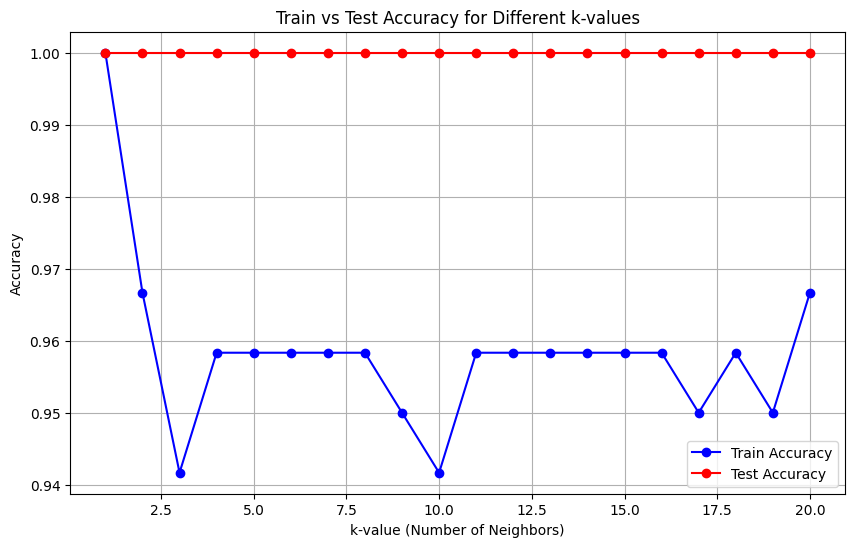

In [44]:PYTHON

```
# Plot confusion matrix
plt.figure(figsize=(8, 6))
sns.heatmap(conf_matrix, annot=True, fmt='d', cmap='Blues', xticklabels=iris.target_names, yticklabels=iris.target_names)
plt.title('Confusion Matrix')
plt.xlabel('Predicted')
plt.ylabel('True')
plt.show()
```

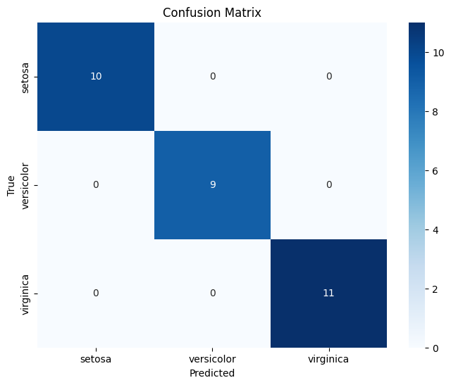

In [45]:PYTHON

```
import seaborn as sns
import pandas as pd
```

In [46]:PYTHON

```
# Load the data into a DataFrame
iris_df = pd.DataFrame(data=iris.data, columns=iris.feature_names)
iris_df['target'] = iris.target

# Pairplot to visualize the relationships between features
sns.pairplot(iris_df, hue='target', palette='Set1', markers=['o', 's', 'D'])
plt.suptitle("Pairplot of Iris Dataset Features", y=1.02)
plt.show()
```

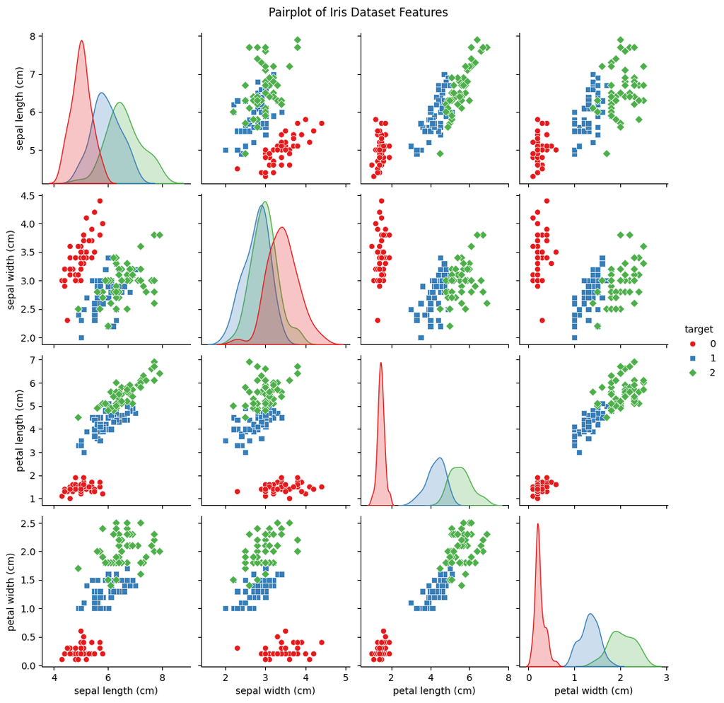

In [47]:PYTHON

```
# Visualizing 2D scatter plots for pairs of features
# Sepal Length vs Sepal Width
plt.figure(figsize=(8, 6))
sns.scatterplot(data=iris_df, x=iris.feature_names[0], y=iris.feature_names[1], hue='target', palette='Set1')
plt.title('Sepal Length vs Sepal Width')
plt.show()

# Petal Length vs Petal Width
plt.figure(figsize=(8, 6))
sns.scatterplot(data=iris_df, x=iris.feature_names[2], y=iris.feature_names[3], hue='target', palette='Set1')
plt.title('Petal Length vs Petal Width')
plt.show()
```

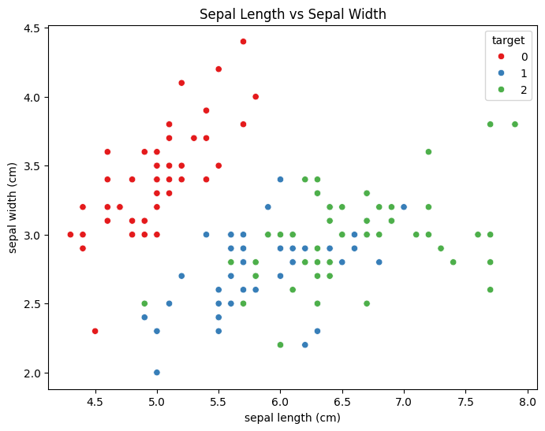

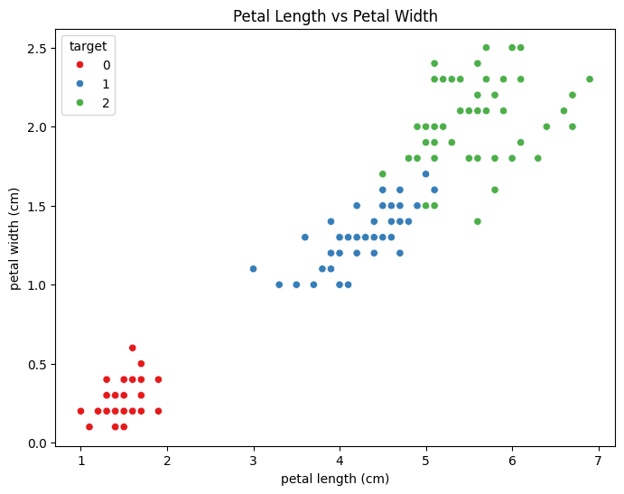

## 📓 Notebook 3: Exploratory Kinematic Feature Engineering (particles.ipynb)

⬇ Download Raw .ipynb

In [1]:PYTHON

```
V
# jupyter:
#   jupytext:
#     text_representation:
#       extension: .py
#       format_name: percent
#       format_version: '1.3'
#       jupytext_version: 1.16.4
#   kernelspec:
#     display_name: Python 3 (ipykernel)
#     language: python
#     name: python3
# ---
```

# Parcial 2, métodos de clasificación con datos del LHC

In [194]:PYTHON

```
import numpy as np
import pandas as pd
import matplotlib.pyplot as plt
from matplotlib import rc
from sklearn.svm import SVC, LinearSVC
from sklearn.preprocessing import StandardScaler
from sklearn.model_selection import cross_val_predict, cross_validate
from sklearn.model_selection import KFold, StratifiedKFold
from sklearn import metrics
from sklearn.model_selection import GridSearchCV
```

In [195]:PYTHON

```
pd.set_option('display.max_columns', 500)
pd.set_option('display.max_rows', 500)
pd.set_option('display.max_colwidth', 100)
rc('text', usetex=False)
```

### Leemos el .csv y nombramos las columnas

In [196]:PYTHON

```
df = pd.read_csv('TrainingValidationData.csv', delimiter=',', names=list(['P'+str(i) for i in range(73)]) )
print(df.columns)
```

```
Index(['P0', 'P1', 'P2', 'P3', 'P4', 'P5', 'P6', 'P7', 'P8', 'P9', 'P10',
       'P11', 'P12', 'P13', 'P14', 'P15', 'P16', 'P17', 'P18', 'P19', 'P20',
       'P21', 'P22', 'P23', 'P24', 'P25', 'P26', 'P27', 'P28', 'P29', 'P30',
       'P31', 'P32', 'P33', 'P34', 'P35', 'P36', 'P37', 'P38', 'P39', 'P40',
       'P41', 'P42', 'P43', 'P44', 'P45', 'P46', 'P47', 'P48', 'P49', 'P50',
       'P51', 'P52', 'P53', 'P54', 'P55', 'P56', 'P57', 'P58', 'P59', 'P60',
       'P61', 'P62', 'P63', 'P64', 'P65', 'P66', 'P67', 'P68', 'P69', 'P70',
       'P71', 'P72'],
      dtype='object')
```

```
/tmp/ipykernel_15868/251479849.py:1: DtypeWarning: Columns (60,64,68,72) have mixed types. Specify dtype option on import or set low_memory=False.
  df = pd.read_csv('TrainingValidationData.csv', delimiter=',', names=list(['P'+str(i) for i in range(73)]) )
```

In [197]:PYTHON

```
df.head()
```

|  | P0 | P1 | P2 | P3 | P4 | P5 | P6 | P7 | P8 | P9 | P10 | P11 | P12 | P13 | P14 | P15 | P16 | P17 | P18 | P19 | P20 | P21 | P22 | P23 | P24 | P25 | P26 | P27 | P28 | … |
| --- | --- | --- | --- | --- | --- | --- | --- | --- | --- | --- | --- | --- | --- | --- | --- | --- | --- | --- | --- | --- | --- | --- | --- | --- | --- | --- | --- | --- | --- | --- |
| 0 | 0;ttbar;0.00167779;17742.1;-2.37367;j | 193103.0 | 143393.0 | 0.803969 | -0.198431;j | 778814.0 | 104707.0 | 2.695040 | -3.03908;j | 125976.0 | 85268.9 | -0.934506 | 3.1025;b | 69106.5 | 55957.8 | -0.661401 | 0.937923;j | 50482.4 | 39522.4 | 0.687292 | 0.839734;j | 82162.7 | 37182.8 | 1.426130 | -0.0749548;j | 638681.0 | 24114.8 | -3.96928 | 3.13769; | … |
| 1 | 1;ttbar;0.00167779;15567.8;-2.90015;b | 183399.0 | 105032.0 | 1.153790 | -2.43549;j | 166852.0 | 93020.5 | 1.186420 | 0.203206;j | 49938.5 | 48836.5 | 0.136584 | 0.00672176;j | 168744.0 | 23995.2 | -2.637880 | 2.31197;e+ | 32046.3 | 27560.8 | 0.563054 | 1.71034; | NaN | NaN | NaN | NaN | NaN | NaN | NaN | NaN | … |
| 2 | 2;ttbar;0.0334195;30647.2;2.74336;j | 420301.0 | 135727.0 | -1.792050 | -0.609116;j | 294268.0 | 78516.8 | -1.994660 | -2.51345;b | 194433.0 | 67511.8 | -1.716620 | 0.314709;j | 78721.8 | 50067.6 | 1.014570 | 1.72546;j | 60548.4 | 50035.6 | 0.620308 | 2.79499;b | 41859.8 | 39719.8 | -0.279838 | -3.04737; | NaN | NaN | NaN | NaN | … |
| 3 | 3;4top;1.93132e-07;27699.6;0.617912;j | 300154.0 | 277869.0 | -0.370231 | -0.684062;j | 261232.0 | 206121.0 | 0.698378 | 1.81692;j | 258771.0 | 166742.0 | -1.006300 | -1.8801;j | 145917.0 | 142031.0 | 0.159003 | 2.47523;j | 67064.7 | 46427.1 | -0.888082 | 2.22281;j | 328441.0 | 43982.4 | 2.698900 | 0.0610803;j | 62307.4 | 28564.1 | 1.39952 | -2.892;m+ | … |
| 4 | 4;ttbar;0.00167779;92205.9;1.57425;j | 140760.0 | 75721.7 | -1.225510 | -2.92616;j | 1650250.0 | 68573.0 | -3.873460 | -0.941662;j | 199485.0 | 39008.3 | -2.314910 | -2.15216;j | 36111.1 | 32994.1 | -0.399817 | 1.25275;j | 133019.0 | 29239.5 | -2.194640 | -0.13927;m- | 31258.4 | 27580.9 | -0.510817 | 2.75758; | NaN | NaN | NaN | NaN | … |

### El dataset trae en P0 6 caracteristicas más, entonces las dividimos.

In [198]:PYTHON

```
new = df['P0'].str.split(';',expand=True)

new.columns = ['numID', 'processID', 'weight', 'MET', 'METphi', 'Type_1']
```

In [199]:PYTHON

```
new.head()
```

|  | numID | processID | weight | MET | METphi | Type_1 |
| --- | --- | --- | --- | --- | --- | --- |
| 0 | 0 | ttbar | 0.00167779 | 17742.1 | -2.37367 | j |
| 1 | 1 | ttbar | 0.00167779 | 15567.8 | -2.90015 | b |
| 2 | 2 | ttbar | 0.0334195 | 30647.2 | 2.74336 | j |
| 3 | 3 | 4top | 1.93132e-07 | 27699.6 | 0.617912 | j |
| 4 | 4 | ttbar | 0.00167779 | 92205.9 | 1.57425 | j |

### Se unen al dataset principal

In [200]:PYTHON

```
df = df.join(new, how='outer') #join them side to side
```

In [201]:PYTHON

```
df.head()
```

|  | P0 | P1 | P2 | P3 | P4 | P5 | P6 | P7 | P8 | P9 | P10 | P11 | P12 | P13 | P14 | P15 | P16 | P17 | P18 | P19 | P20 | P21 | P22 | P23 | P24 | P25 | P26 | P27 | P28 | … |
| --- | --- | --- | --- | --- | --- | --- | --- | --- | --- | --- | --- | --- | --- | --- | --- | --- | --- | --- | --- | --- | --- | --- | --- | --- | --- | --- | --- | --- | --- | --- |
| 0 | 0;ttbar;0.00167779;17742.1;-2.37367;j | 193103.0 | 143393.0 | 0.803969 | -0.198431;j | 778814.0 | 104707.0 | 2.695040 | -3.03908;j | 125976.0 | 85268.9 | -0.934506 | 3.1025;b | 69106.5 | 55957.8 | -0.661401 | 0.937923;j | 50482.4 | 39522.4 | 0.687292 | 0.839734;j | 82162.7 | 37182.8 | 1.426130 | -0.0749548;j | 638681.0 | 24114.8 | -3.96928 | 3.13769; | … |
| 1 | 1;ttbar;0.00167779;15567.8;-2.90015;b | 183399.0 | 105032.0 | 1.153790 | -2.43549;j | 166852.0 | 93020.5 | 1.186420 | 0.203206;j | 49938.5 | 48836.5 | 0.136584 | 0.00672176;j | 168744.0 | 23995.2 | -2.637880 | 2.31197;e+ | 32046.3 | 27560.8 | 0.563054 | 1.71034; | NaN | NaN | NaN | NaN | NaN | NaN | NaN | NaN | … |
| 2 | 2;ttbar;0.0334195;30647.2;2.74336;j | 420301.0 | 135727.0 | -1.792050 | -0.609116;j | 294268.0 | 78516.8 | -1.994660 | -2.51345;b | 194433.0 | 67511.8 | -1.716620 | 0.314709;j | 78721.8 | 50067.6 | 1.014570 | 1.72546;j | 60548.4 | 50035.6 | 0.620308 | 2.79499;b | 41859.8 | 39719.8 | -0.279838 | -3.04737; | NaN | NaN | NaN | NaN | … |
| 3 | 3;4top;1.93132e-07;27699.6;0.617912;j | 300154.0 | 277869.0 | -0.370231 | -0.684062;j | 261232.0 | 206121.0 | 0.698378 | 1.81692;j | 258771.0 | 166742.0 | -1.006300 | -1.8801;j | 145917.0 | 142031.0 | 0.159003 | 2.47523;j | 67064.7 | 46427.1 | -0.888082 | 2.22281;j | 328441.0 | 43982.4 | 2.698900 | 0.0610803;j | 62307.4 | 28564.1 | 1.39952 | -2.892;m+ | … |
| 4 | 4;ttbar;0.00167779;92205.9;1.57425;j | 140760.0 | 75721.7 | -1.225510 | -2.92616;j | 1650250.0 | 68573.0 | -3.873460 | -0.941662;j | 199485.0 | 39008.3 | -2.314910 | -2.15216;j | 36111.1 | 32994.1 | -0.399817 | 1.25275;j | 133019.0 | 29239.5 | -2.194640 | -0.13927;m- | 31258.4 | 27580.9 | -0.510817 | 2.75758; | NaN | NaN | NaN | NaN | … |

### Convertimos Type_1 en 14 columnas

In [202]:PYTHON

```
for i in range(4,53,4):

    new = df['P'+str(i)].str.split(';',expand=True)

    df['P'+str(i)] = new[0]

    df['Type_'+str(int(i/4+1))] = new[1]

print(df.columns)
```

```
Index(['P0', 'P1', 'P2', 'P3', 'P4', 'P5', 'P6', 'P7', 'P8', 'P9', 'P10',
       'P11', 'P12', 'P13', 'P14', 'P15', 'P16', 'P17', 'P18', 'P19', 'P20',
       'P21', 'P22', 'P23', 'P24', 'P25', 'P26', 'P27', 'P28', 'P29', 'P30',
       'P31', 'P32', 'P33', 'P34', 'P35', 'P36', 'P37', 'P38', 'P39', 'P40',
       'P41', 'P42', 'P43', 'P44', 'P45', 'P46', 'P47', 'P48', 'P49', 'P50',
       'P51', 'P52', 'P53', 'P54', 'P55', 'P56', 'P57', 'P58', 'P59', 'P60',
       'P61', 'P62', 'P63', 'P64', 'P65', 'P66', 'P67', 'P68', 'P69', 'P70',
       'P71', 'P72', 'numID', 'processID', 'weight', 'MET', 'METphi', 'Type_1',
       'Type_2', 'Type_3', 'Type_4', 'Type_5', 'Type_6', 'Type_7', 'Type_8',
       'Type_9', 'Type_10', 'Type_11', 'Type_12', 'Type_13', 'Type_14'],
      dtype='object')
```

In [203]:PYTHON

```
df = df.drop('P0', axis=1)
```

In [204]:PYTHON

```
df.columns.values
```

```
array(['P1', 'P2', 'P3', 'P4', 'P5', 'P6', 'P7', 'P8', 'P9', 'P10', 'P11',
       'P12', 'P13', 'P14', 'P15', 'P16', 'P17', 'P18', 'P19', 'P20',
       'P21', 'P22', 'P23', 'P24', 'P25', 'P26', 'P27', 'P28', 'P29',
       'P30', 'P31', 'P32', 'P33', 'P34', 'P35', 'P36', 'P37', 'P38',
       'P39', 'P40', 'P41', 'P42', 'P43', 'P44', 'P45', 'P46', 'P47',
       'P48', 'P49', 'P50', 'P51', 'P52', 'P53', 'P54', 'P55', 'P56',
       'P57', 'P58', 'P59', 'P60', 'P61', 'P62', 'P63', 'P64', 'P65',
       'P66', 'P67', 'P68', 'P69', 'P70', 'P71', 'P72', 'numID',
       'processID', 'weight', 'MET', 'METphi', 'Type_1', 'Type_2',
       'Type_3', 'Type_4', 'Type_5', 'Type_6', 'Type_7', 'Type_8',
       'Type_9', 'Type_10', 'Type_11', 'Type_12', 'Type_13', 'Type_14'],
      dtype=object)
```

### Ordenamos

In [205]:PYTHON

```
#just re-ordering

cols = ['numID', 'processID', 'weight',
       'MET', 'METphi', 'Type_1', 'P1', 'P2', 'P3', 'P4',  'Type_2', 'P5', 'P6', 'P7', 'P8', 'Type_3', 'P9', 'P10', 'P11',
       'P12',  'Type_4', 'P13', 'P14', 'P15', 'P16', 'Type_5','P17', 'P18', 'P19', 'P20',
       'Type_6','P21', 'P22', 'P23', 'P24', 'Type_7','P25', 'P26', 'P27', 'P28', 'Type_8','P29',
       'P30', 'P31', 'P32', 'Type_9', 'P33', 'P34', 'P35', 'P36', 'Type_10','P37', 'P38',
       'P39', 'P40', 'Type_11', 'P41', 'P42', 'P43', 'P44', 'Type_12', 'P45', 'P46', 'P47',
       'P48', 'Type_13','P49', 'P50', 'P51', 'P52']
```

In [206]:PYTHON

```
X = df[cols].drop(['numID', 'processID', 'weight'], axis = 1)
```

In [207]:PYTHON

```
len(cols)
```

```
70
```

In [208]:PYTHON

```
X.head()
```

|  | MET | METphi | Type_1 | P1 | P2 | P3 | P4 | Type_2 | P5 | P6 | P7 | P8 | Type_3 | P9 | P10 | P11 | P12 | Type_4 | P13 | P14 | P15 | P16 | Type_5 | P17 | P18 | P19 | P20 | Type_6 | P21 | … |
| --- | --- | --- | --- | --- | --- | --- | --- | --- | --- | --- | --- | --- | --- | --- | --- | --- | --- | --- | --- | --- | --- | --- | --- | --- | --- | --- | --- | --- | --- | --- |
| 0 | 17742.1 | -2.37367 | j | 193103.0 | 143393.0 | 0.803969 | -0.198431 | j | 778814.0 | 104707.0 | 2.695040 | -3.03908 | j | 125976.0 | 85268.9 | -0.934506 | 3.1025 | b | 69106.5 | 55957.8 | -0.661401 | 0.937923 | j | 50482.4 | 39522.4 | 0.687292 | 0.839734 | j | 82162.7 | … |
| 1 | 15567.8 | -2.90015 | b | 183399.0 | 105032.0 | 1.153790 | -2.43549 | j | 166852.0 | 93020.5 | 1.186420 | 0.203206 | j | 49938.5 | 48836.5 | 0.136584 | 0.00672176 | j | 168744.0 | 23995.2 | -2.637880 | 2.31197 | e+ | 32046.3 | 27560.8 | 0.563054 | 1.71034 |  | NaN | … |
| 2 | 30647.2 | 2.74336 | j | 420301.0 | 135727.0 | -1.792050 | -0.609116 | j | 294268.0 | 78516.8 | -1.994660 | -2.51345 | b | 194433.0 | 67511.8 | -1.716620 | 0.314709 | j | 78721.8 | 50067.6 | 1.014570 | 1.72546 | j | 60548.4 | 50035.6 | 0.620308 | 2.79499 | b | 41859.8 | … |
| 3 | 27699.6 | 0.617912 | j | 300154.0 | 277869.0 | -0.370231 | -0.684062 | j | 261232.0 | 206121.0 | 0.698378 | 1.81692 | j | 258771.0 | 166742.0 | -1.006300 | -1.8801 | j | 145917.0 | 142031.0 | 0.159003 | 2.47523 | j | 67064.7 | 46427.1 | -0.888082 | 2.22281 | j | 328441.0 | … |
| 4 | 92205.9 | 1.57425 | j | 140760.0 | 75721.7 | -1.225510 | -2.92616 | j | 1650250.0 | 68573.0 | -3.873460 | -0.941662 | j | 199485.0 | 39008.3 | -2.314910 | -2.15216 | j | 36111.1 | 32994.1 | -0.399817 | 1.25275 | j | 133019.0 | 29239.5 | -2.194640 | -0.13927 | m- | 31258.4 | … |

In [209]:PYTHON

```
X.describe()
```

|  | P1 | P2 | P3 | P5 | P6 | P7 | P9 | P10 | P11 | P13 | P14 | P15 | P17 | P18 | P19 | P21 | P22 | P23 | P25 | P26 | P27 | P29 | P30 | P31 | P33 | P34 | P35 | P37 | P38 | … |
| --- | --- | --- | --- | --- | --- | --- | --- | --- | --- | --- | --- | --- | --- | --- | --- | --- | --- | --- | --- | --- | --- | --- | --- | --- | --- | --- | --- | --- | --- | --- |
| count | 9.999700e+04 | 9.999700e+04 | 99997.000000 | 9.992600e+04 | 9.992600e+04 | 99926.000000 | 9.899100e+04 | 98991.000000 | 98991.000000 | 9.385300e+04 | 93853.000000 | 93853.000000 | 7.991000e+04 | 79910.000000 | 79910.000000 | 5.853900e+04 | 58539.000000 | 58539.000000 | 3.834700e+04 | 38347.000000 | 38347.000000 | 2.412200e+04 | 24122.000000 | 24122.000000 | 1.513400e+04 | 15134.000000 | 15134.000000 | 9.011000e+03 | 9011.000000 | … |
| mean | 3.277655e+05 | 1.545569e+05 | -0.003555 | 2.502158e+05 | 1.077661e+05 | 0.002952 | 2.060598e+05 | 74817.281537 | -0.002819 | 1.824161e+05 | 57910.555406 | -0.002839 | 1.721824e+05 | 48861.000075 | -0.004951 | 1.684729e+05 | 44167.725923 | -0.002462 | 1.664557e+05 | 41661.123342 | -0.000830 | 1.651800e+05 | 40757.138956 | 0.003005 | 1.654103e+05 | 40760.175268 | 0.000550 | 1.615391e+05 | 40610.894030 | … |
| std | 2.992857e+05 | 1.123455e+05 | 1.350584 | 2.563849e+05 | 7.614375e+04 | 1.422386 | 2.472275e+05 | 44171.199946 | 1.542322 | 2.388193e+05 | 31288.049544 | 1.640667 | 2.406316e+05 | 25329.276228 | 1.721809 | 2.368950e+05 | 22788.335816 | 1.788698 | 2.337867e+05 | 22879.841904 | 1.834066 | 2.340694e+05 | 25917.855025 | 1.852271 | 2.272069e+05 | 30147.319141 | 1.878538 | 2.197876e+05 | 34899.356724 | … |
| min | 2.089250e+04 | 1.838530e+04 | -4.856300 | 1.087540e+04 | 1.007280e+04 | -4.788360 | 1.027220e+04 | 10023.400000 | -4.892440 | 1.001200e+04 | 10004.200000 | -4.897010 | 1.034400e+04 | 10006.000000 | -4.893080 | 1.028280e+04 | 10006.500000 | -4.930230 | 1.013400e+04 | 10009.700000 | -4.920570 | 1.048510e+04 | 10060.300000 | -4.921770 | 1.022420e+04 | 10009.300000 | -4.884880 | 1.047610e+04 | 10046.100000 | … |
| 25% | 1.371900e+05 | 8.806960e+04 | -0.987878 | 9.961973e+04 | 6.373630e+04 | -1.009580 | 7.534165e+04 | 47026.900000 | -1.078880 | 6.102030e+04 | 36720.200000 | -1.143060 | 5.329685e+04 | 31383.600000 | -1.198820 | 4.980905e+04 | 28825.100000 | -1.250715 | 4.830010e+04 | 27846.900000 | -1.281040 | 4.725082e+04 | 27306.075000 | -1.306000 | 4.541188e+04 | 26804.550000 | -1.324485 | 4.401945e+04 | 26325.600000 | … |
| 50% | 2.262300e+05 | 1.196960e+05 | -0.003297 | 1.640690e+05 | 8.635380e+04 | -0.002509 | 1.250130e+05 | 63189.700000 | -0.006581 | 1.025380e+05 | 49475.900000 | -0.006059 | 9.069685e+04 | 41449.600000 | -0.006588 | 8.574750e+04 | 37348.500000 | -0.001917 | 8.353000e+04 | 35312.000000 | -0.008763 | 8.144470e+04 | 34131.000000 | -0.003657 | 8.182995e+04 | 32771.700000 | -0.010745 | 7.986780e+04 | 31232.700000 | … |
| 75% | 4.073950e+05 | 1.774540e+05 | 0.987178 | 2.999222e+05 | 1.248410e+05 | 1.014055 | 2.319710e+05 | 89264.600000 | 1.078430 | 1.976550e+05 | 69872.000000 | 1.136430 | 1.799680e+05 | 58829.725000 | 1.189717 | 1.767390e+05 | 52490.200000 | 1.254020 | 1.772160e+05 | 48534.650000 | 1.301125 | 1.750300e+05 | 45545.350000 | 1.320450 | 1.822572e+05 | 42861.950000 | 1.336267 | 1.825300e+05 | 40546.250000 | … |
| max | 3.783780e+06 | 1.768980e+06 | 4.796060 | 4.379710e+06 | 1.687820e+06 | 4.810550 | 3.823240e+06 | 788338.000000 | 4.844930 | 4.126560e+06 | 481884.000000 | 4.887670 | 3.835360e+06 | 499118.000000 | 4.900040 | 3.833440e+06 | 504952.000000 | 4.943350 | 3.093440e+06 | 545365.000000 | 4.879880 | 3.167930e+06 | 860415.000000 | 4.866710 | 2.590720e+06 | 679264.000000 | 4.873490 | 2.296100e+06 | 732108.000000 | … |

Some columns that should be numerical are of type "object"

In [210]:PYTHON

```
X.columns[X.dtypes == object]
```

```
Index(['MET', 'METphi', 'Type_1', 'P4', 'Type_2', 'P8', 'Type_3', 'P12',
       'Type_4', 'P16', 'Type_5', 'P20', 'Type_6', 'P24', 'Type_7', 'P28',
       'Type_8', 'P32', 'Type_9', 'P36', 'Type_10', 'P40', 'Type_11', 'P44',
       'Type_12', 'P48', 'Type_13', 'P52'],
      dtype='object')
```

### formateamos al correcto

In [211]:PYTHON

```
for el in ['MET', 'METphi', 'P4', 'P8', 'P12',
        'P16',  'P20', 'P24',  'P28',
    'P32', 'P36', 'P40', 'P44',
      'P48', 'P52']:
    X[el] = X[el].astype('float64')
```

In [212]:PYTHON

```
X.dtypes
```

```
MET        float64
METphi     float64
Type_1      object
P1         float64
P2         float64
P3         float64
P4         float64
Type_2      object
P5         float64
P6         float64
P7         float64
P8         float64
Type_3      object
P9         float64
P10        float64
P11        float64
P12        float64
Type_4      object
P13        float64
P14        float64
P15        float64
P16        float64
Type_5      object
P17        float64
P18        float64
P19        float64
P20        float64
Type_6      object
P21        float64
P22        float64
P23        float64
P24        float64
Type_7      object
P25        float64
P26        float64
P27        float64
P28        float64
Type_8      object
P29        float64
P30        float64
P31        float64
P32        float64
Type_9      object
P33        float64
P34        float64
P35        float64
P36        float64
Type_10     object
P37        float64
P38        float64
P39        float64
P40        float64
Type_11     object
P41        float64
P42        float64
P43        float64
P44        float64
Type_12     object
P45        float64
P46        float64
P47        float64
P48        float64
Type_13     object
P49        float64
P50        float64
P51        float64
P52        float64
dtype: object
```

### Selecionamos solamente 5000 datos para que sea manipulable

In [213]:PYTHON

```
np.random.seed(10)

sel = np.random.choice(df.shape[0], 5000)

features = X.iloc[sel,:]
```

In [214]:PYTHON

```
features.shape
```

```
(5000, 67)
```

In [215]:PYTHON

```
features.columns
```

```
Index(['MET', 'METphi', 'Type_1', 'P1', 'P2', 'P3', 'P4', 'Type_2', 'P5', 'P6',
       'P7', 'P8', 'Type_3', 'P9', 'P10', 'P11', 'P12', 'Type_4', 'P13', 'P14',
       'P15', 'P16', 'Type_5', 'P17', 'P18', 'P19', 'P20', 'Type_6', 'P21',
       'P22', 'P23', 'P24', 'Type_7', 'P25', 'P26', 'P27', 'P28', 'Type_8',
       'P29', 'P30', 'P31', 'P32', 'Type_9', 'P33', 'P34', 'P35', 'P36',
       'Type_10', 'P37', 'P38', 'P39', 'P40', 'Type_11', 'P41', 'P42', 'P43',
       'P44', 'Type_12', 'P45', 'P46', 'P47', 'P48', 'Type_13', 'P49', 'P50',
       'P51', 'P52'],
      dtype='object')
```

### reseteamos indices

In [216]:PYTHON

```
features.reset_index(drop=True, inplace=True)
```

In [217]:PYTHON

```
features.head()
```

|  | MET | METphi | Type_1 | P1 | P2 | P3 | P4 | Type_2 | P5 | P6 | P7 | P8 | Type_3 | P9 | P10 | P11 | P12 | Type_4 | P13 | P14 | P15 | P16 | Type_5 | P17 | P18 | P19 | P20 | Type_6 | P21 | … |
| --- | --- | --- | --- | --- | --- | --- | --- | --- | --- | --- | --- | --- | --- | --- | --- | --- | --- | --- | --- | --- | --- | --- | --- | --- | --- | --- | --- | --- | --- | --- |
| 0 | 62803.5 | -1.810010 | j | 137571.0 | 128444.0 | -0.345744 | -0.307112 | j | 174209.0 | 127932.0 | 0.826569 | 2.332000 | b | 86788.9 | 84554.9 | -0.180795 | 2.187970 | j | 140289.0 | 76955.8 | -1.19933 | -1.302800 | m+ | 85230.6 | 70102.4 | -0.645689 | -1.659540 |  | NaN | … |
| 1 | 57594.2 | -0.509253 | j | 161529.0 | 80458.3 | -1.318010 | 1.402050 | j | 291490.0 | 68462.9 | -2.126740 | -2.582310 | e- | 44270.1 | 35139.6 | -0.706120 | -0.371392 | e+ | 72883.9 | 26902.2 | -1.65386 | -3.129630 |  | NaN | NaN | NaN | NaN | NaN | NaN | … |
| 2 | 82313.3 | 1.686840 | b | 167130.0 | 113078.0 | 0.937258 | -2.068680 | j | 102423.0 | 54922.3 | 1.226850 | 0.646589 | j | 60768.9 | 36244.3 | 1.102890 | -1.434480 | j | 77714.0 | 27801.5 | 1.68461 | 1.389690 | j | 26840.0 | 24469.3 | -0.388937 | -1.647260 |  | NaN | … |
| 3 | 30610.8 | 2.617120 | j | 112267.0 | 61383.9 | -1.211050 | -1.457800 | b | 40647.8 | 39472.0 | -0.024646 | -2.222800 | j | 201589.0 | 32978.6 | -2.496040 | 1.137810 | j | 90096.7 | 26964.5 | 1.87132 | 0.817631 | j | 28235.4 | 25887.9 | -0.411528 | 2.024290 |  | NaN | … |
| 4 | 45153.1 | -2.241350 | j | 178174.0 | 100164.0 | 1.166880 | -0.018721 | j | 92351.3 | 69762.1 | 0.774114 | 2.568740 | j | 61625.2 | 50086.7 | 0.652572 | -3.012800 | j | 104193.0 | 31151.0 | 1.87641 | 0.865381 | j | 746585.0 | 26219.3 | 4.041820 | -0.874169 |  | NaN | … |

### Exportamos las caracteristicas

In [218]:PYTHON

```
features.to_csv('ParticleID_features.csv', index_label= 'ID')
```

#### Seleccionamos los target

In [219]:PYTHON

```
y = df.processID[sel].values # values makes it an array
```

In [220]:PYTHON

```
y
```

```
array(['ttbar', 'ttbar', 'ttbar', ..., 'ttbar', '4top', 'ttbar'],
      dtype=object)
```

### Los exportamos

In [221]:PYTHON

```
np.savetxt('ParticleID_labels.txt', y, fmt = '%s')
```

## Iniciamos el analisis:

In [222]:PYTHON

```
features = pd.read_csv('ParticleID_features.csv', index_col='ID')
```

In [223]:PYTHON

```
features.head()
```

| ID | MET | METphi | Type_1 | P1 | P2 | P3 | P4 | Type_2 | P5 | P6 | P7 | P8 | Type_3 | P9 | P10 | P11 | P12 | Type_4 | P13 | P14 | P15 | P16 | Type_5 | P17 | P18 | P19 | P20 | Type_6 | P21 | … |
| --- | --- | --- | --- | --- | --- | --- | --- | --- | --- | --- | --- | --- | --- | --- | --- | --- | --- | --- | --- | --- | --- | --- | --- | --- | --- | --- | --- | --- | --- | --- |
| 0 | 62803.5 | -1.810010 | j | 137571.0 | 128444.0 | -0.345744 | -0.307112 | j | 174209.0 | 127932.0 | 0.826569 | 2.332000 | b | 86788.9 | 84554.9 | -0.180795 | 2.187970 | j | 140289.0 | 76955.8 | -1.19933 | -1.302800 | m+ | 85230.6 | 70102.4 | -0.645689 | -1.659540 | NaN | NaN | … |
| 1 | 57594.2 | -0.509253 | j | 161529.0 | 80458.3 | -1.318010 | 1.402050 | j | 291490.0 | 68462.9 | -2.126740 | -2.582310 | e- | 44270.1 | 35139.6 | -0.706120 | -0.371392 | e+ | 72883.9 | 26902.2 | -1.65386 | -3.129630 | NaN | NaN | NaN | NaN | NaN | NaN | NaN | … |
| 2 | 82313.3 | 1.686840 | b | 167130.0 | 113078.0 | 0.937258 | -2.068680 | j | 102423.0 | 54922.3 | 1.226850 | 0.646589 | j | 60768.9 | 36244.3 | 1.102890 | -1.434480 | j | 77714.0 | 27801.5 | 1.68461 | 1.389690 | j | 26840.0 | 24469.3 | -0.388937 | -1.647260 | NaN | NaN | … |
| 3 | 30610.8 | 2.617120 | j | 112267.0 | 61383.9 | -1.211050 | -1.457800 | b | 40647.8 | 39472.0 | -0.024646 | -2.222800 | j | 201589.0 | 32978.6 | -2.496040 | 1.137810 | j | 90096.7 | 26964.5 | 1.87132 | 0.817631 | j | 28235.4 | 25887.9 | -0.411528 | 2.024290 | NaN | NaN | … |
| 4 | 45153.1 | -2.241350 | j | 178174.0 | 100164.0 | 1.166880 | -0.018721 | j | 92351.3 | 69762.1 | 0.774114 | 2.568740 | j | 61625.2 | 50086.7 | 0.652572 | -3.012800 | j | 104193.0 | 31151.0 | 1.87641 | 0.865381 | j | 746585.0 | 26219.3 | 4.041820 | -0.874169 | NaN | NaN | … |

In [224]:PYTHON

```
features.shape
```

```
(5000, 67)
```

In [225]:PYTHON

```
y = np.genfromtxt('ParticleID_labels.txt', dtype = str)
```

In [226]:PYTHON

```
y
```

```
array(['ttbar', 'ttbar', 'ttbar', ..., 'ttbar', '4top', 'ttbar'],
      dtype='<U5')
```

### convertimos el target en 0 y 1

In [227]:PYTHON

```
from sklearn.preprocessing import LabelEncoder

le = LabelEncoder() #turns categorical into 1 ... N
```

In [228]:PYTHON

```
y
```

```
array(['ttbar', 'ttbar', 'ttbar', ..., 'ttbar', '4top', 'ttbar'],
      dtype='<U5')
```

In [229]:PYTHON

```
y = le.fit_transform(y)
```

In [230]:PYTHON

```
y
```

```
array([1, 1, 1, ..., 1, 0, 1])
```

### invertimos los numeros por comodidad

In [231]:PYTHON

```
target = np.abs(y - 1)
```

In [232]:PYTHON

```
target
```

```
array([0, 0, 0, ..., 0, 1, 0])
```

### Solo consideramos las primeras 16 columnas (los primeros cuatro productos) para que tengamos problemas de imputación/manipulación limitados.

Tenemos que elegir entre mantener más características, pero tener un problema de imputación/datos faltantes más grave, o mantener menos características, pero lidiar con un problema de imputación más simple. Elegimos la segunda opción.

In [233]:PYTHON

```
features_lim = features[['MET', 'METphi', 'P1', 'P2', 'P3', 'P4', 'P5', 'P6', 'P7', 'P8', 'P9', 'P10', 'P11',
       'P12',  'P13', 'P14', 'P15', 'P16']]

features_lim.describe()
```

|  | MET | METphi | P1 | P2 | P3 | P4 | P5 | P6 | P7 | P8 | P9 | P10 | P11 | P12 | P13 | P14 | P15 | P16 |
| --- | --- | --- | --- | --- | --- | --- | --- | --- | --- | --- | --- | --- | --- | --- | --- | --- | --- | --- |
| count | 5000.000000 | 5000.000000 | 5.000000e+03 | 5.000000e+03 | 5000.000000 | 5000.000000 | 4.997000e+03 | 4.997000e+03 | 4997.000000 | 4997.000000 | 4.950000e+03 | 4950.000000 | 4950.000000 | 4950.000000 | 4.717000e+03 | 4717.000000 | 4717.000000 | 4717.000000 |
| mean | 64071.074332 | -0.028916 | 3.301357e+05 | 1.540486e+05 | -0.039812 | -0.003049 | 2.527799e+05 | 1.080302e+05 | -0.029936 | 0.007327 | 2.117980e+05 | 74863.343131 | -0.025104 | 0.011845 | 1.805997e+05 | 57289.049481 | 0.010723 | 0.045266 |
| std | 60525.122480 | 1.819257 | 3.068202e+05 | 1.149469e+05 | 1.361762 | 1.814855 | 2.638580e+05 | 8.136261e+04 | 1.439105 | 1.828832 | 2.510361e+05 | 46309.512365 | 1.577316 | 1.802715 | 2.383403e+05 | 32013.857623 | 1.634072 | 1.812078 |
| min | 290.756000 | -3.141010 | 3.857940e+04 | 2.825400e+04 | -4.110220 | -3.140710 | 1.087540e+04 | 1.080000e+04 | -4.668790 | -3.140530 | 1.221050e+04 | 10639.800000 | -4.520250 | -3.141480 | 1.169190e+04 | 10818.000000 | -4.616550 | -3.136130 |
| 25% | 24352.375000 | -1.619905 | 1.369522e+05 | 8.883690e+04 | -1.035570 | -1.574213 | 1.007510e+05 | 6.321840e+04 | -1.060500 | -1.602460 | 7.636905e+04 | 46549.475000 | -1.125620 | -1.547418 | 5.999090e+04 | 36097.700000 | -1.121240 | -1.518030 |
| 50% | 46814.400000 | -0.055612 | 2.263525e+05 | 1.182015e+05 | -0.038731 | -0.009037 | 1.659740e+05 | 8.584360e+04 | -0.057429 | 0.015111 | 1.288565e+05 | 62498.400000 | -0.040648 | 0.034238 | 9.922610e+04 | 48949.200000 | -0.035512 | 0.060279 |
| 75% | 83032.350000 | 1.537323 | 4.077158e+05 | 1.771265e+05 | 0.943598 | 1.542370 | 2.999950e+05 | 1.238700e+05 | 1.028340 | 1.605210 | 2.421225e+05 | 89587.500000 | 1.066302 | 1.570887 | 1.914340e+05 | 68782.100000 | 1.159480 | 1.612220 |
| max | 692674.000000 | 3.141130 | 3.186360e+06 | 1.276710e+06 | 4.141410 | 3.138540 | 3.587700e+06 | 1.146330e+06 | 4.559150 | 3.139200 | 2.800410e+06 | 788338.000000 | 4.798090 | 3.139020 | 2.503590e+06 | 481884.000000 | 4.730480 | 3.139660 |

In [234]:PYTHON

```
features_lim.head()
```

| ID | MET | METphi | P1 | P2 | P3 | P4 | P5 | P6 | P7 | P8 | P9 | P10 | P11 | P12 | P13 | P14 | P15 | P16 |
| --- | --- | --- | --- | --- | --- | --- | --- | --- | --- | --- | --- | --- | --- | --- | --- | --- | --- | --- |
| 0 | 62803.5 | -1.810010 | 137571.0 | 128444.0 | -0.345744 | -0.307112 | 174209.0 | 127932.0 | 0.826569 | 2.332000 | 86788.9 | 84554.9 | -0.180795 | 2.187970 | 140289.0 | 76955.8 | -1.19933 | -1.302800 |
| 1 | 57594.2 | -0.509253 | 161529.0 | 80458.3 | -1.318010 | 1.402050 | 291490.0 | 68462.9 | -2.126740 | -2.582310 | 44270.1 | 35139.6 | -0.706120 | -0.371392 | 72883.9 | 26902.2 | -1.65386 | -3.129630 |
| 2 | 82313.3 | 1.686840 | 167130.0 | 113078.0 | 0.937258 | -2.068680 | 102423.0 | 54922.3 | 1.226850 | 0.646589 | 60768.9 | 36244.3 | 1.102890 | -1.434480 | 77714.0 | 27801.5 | 1.68461 | 1.389690 |
| 3 | 30610.8 | 2.617120 | 112267.0 | 61383.9 | -1.211050 | -1.457800 | 40647.8 | 39472.0 | -0.024646 | -2.222800 | 201589.0 | 32978.6 | -2.496040 | 1.137810 | 90096.7 | 26964.5 | 1.87132 | 0.817631 |
| 4 | 45153.1 | -2.241350 | 178174.0 | 100164.0 | 1.166880 | -0.018721 | 92351.3 | 69762.1 | 0.774114 | 2.568740 | 61625.2 | 50086.7 | 0.652572 | -3.012800 | 104193.0 | 31151.0 | 1.87641 | 0.865381 |

In [235]:PYTHON

```
features_lim.describe()
```

|  | MET | METphi | P1 | P2 | P3 | P4 | P5 | P6 | P7 | P8 | P9 | P10 | P11 | P12 | P13 | P14 | P15 | P16 |
| --- | --- | --- | --- | --- | --- | --- | --- | --- | --- | --- | --- | --- | --- | --- | --- | --- | --- | --- |
| count | 5000.000000 | 5000.000000 | 5.000000e+03 | 5.000000e+03 | 5000.000000 | 5000.000000 | 4.997000e+03 | 4.997000e+03 | 4997.000000 | 4997.000000 | 4.950000e+03 | 4950.000000 | 4950.000000 | 4950.000000 | 4.717000e+03 | 4717.000000 | 4717.000000 | 4717.000000 |
| mean | 64071.074332 | -0.028916 | 3.301357e+05 | 1.540486e+05 | -0.039812 | -0.003049 | 2.527799e+05 | 1.080302e+05 | -0.029936 | 0.007327 | 2.117980e+05 | 74863.343131 | -0.025104 | 0.011845 | 1.805997e+05 | 57289.049481 | 0.010723 | 0.045266 |
| std | 60525.122480 | 1.819257 | 3.068202e+05 | 1.149469e+05 | 1.361762 | 1.814855 | 2.638580e+05 | 8.136261e+04 | 1.439105 | 1.828832 | 2.510361e+05 | 46309.512365 | 1.577316 | 1.802715 | 2.383403e+05 | 32013.857623 | 1.634072 | 1.812078 |
| min | 290.756000 | -3.141010 | 3.857940e+04 | 2.825400e+04 | -4.110220 | -3.140710 | 1.087540e+04 | 1.080000e+04 | -4.668790 | -3.140530 | 1.221050e+04 | 10639.800000 | -4.520250 | -3.141480 | 1.169190e+04 | 10818.000000 | -4.616550 | -3.136130 |
| 25% | 24352.375000 | -1.619905 | 1.369522e+05 | 8.883690e+04 | -1.035570 | -1.574213 | 1.007510e+05 | 6.321840e+04 | -1.060500 | -1.602460 | 7.636905e+04 | 46549.475000 | -1.125620 | -1.547418 | 5.999090e+04 | 36097.700000 | -1.121240 | -1.518030 |
| 50% | 46814.400000 | -0.055612 | 2.263525e+05 | 1.182015e+05 | -0.038731 | -0.009037 | 1.659740e+05 | 8.584360e+04 | -0.057429 | 0.015111 | 1.288565e+05 | 62498.400000 | -0.040648 | 0.034238 | 9.922610e+04 | 48949.200000 | -0.035512 | 0.060279 |
| 75% | 83032.350000 | 1.537323 | 4.077158e+05 | 1.771265e+05 | 0.943598 | 1.542370 | 2.999950e+05 | 1.238700e+05 | 1.028340 | 1.605210 | 2.421225e+05 | 89587.500000 | 1.066302 | 1.570887 | 1.914340e+05 | 68782.100000 | 1.159480 | 1.612220 |
| max | 692674.000000 | 3.141130 | 3.186360e+06 | 1.276710e+06 | 4.141410 | 3.138540 | 3.587700e+06 | 1.146330e+06 | 4.559150 | 3.139200 | 2.800410e+06 | 788338.000000 | 4.798090 | 3.139020 | 2.503590e+06 | 481884.000000 | 4.730480 | 3.139660 |

¡Aún quedan algunas columnas de características con longitudes diferentes! Esto significa que puede haber valores NaN. Reemplácelos por 0 por el momento.

In [236]:PYTHON

```
features_lim = features_lim.fillna(0) #Fill with 0 everywhere there is a NaN
```

Nota: esta es la opción más simple pero la peor posible: imputar un valor constante distorsiona el modelo :D Un paso más sería ingresar la media o la mediana para cada columna. Sin embargo, debido a que solo una cantidad limitada de instancias tienen datos faltantes, la elección de la estrategia de imputación no importa demasiado.

In [237]:PYTHON

```
features_lim.describe()
```

|  | MET | METphi | P1 | P2 | P3 | P4 | P5 | P6 | P7 | P8 | P9 | P10 | P11 | P12 | P13 | P14 | P15 | P16 |
| --- | --- | --- | --- | --- | --- | --- | --- | --- | --- | --- | --- | --- | --- | --- | --- | --- | --- | --- |
| count | 5000.000000 | 5000.000000 | 5.000000e+03 | 5.000000e+03 | 5000.000000 | 5000.000000 | 5.000000e+03 | 5.000000e+03 | 5000.000000 | 5000.000000 | 5.000000e+03 | 5000.000000 | 5000.000000 | 5000.000000 | 5.000000e+03 | 5000.000000 | 5000.000000 | 5000.000000 |
| mean | 64071.074332 | -0.028916 | 3.301357e+05 | 1.540486e+05 | -0.039812 | -0.003049 | 2.526283e+05 | 1.079653e+05 | -0.029918 | 0.007323 | 2.096800e+05 | 74114.709700 | -0.024853 | 0.011727 | 1.703778e+05 | 54046.489280 | 0.010116 | 0.042704 |
| std | 60525.122480 | 1.819257 | 3.068202e+05 | 1.149469e+05 | 1.361762 | 1.814855 | 2.638514e+05 | 8.138121e+04 | 1.438673 | 1.828283 | 2.506651e+05 | 46675.655162 | 1.569410 | 1.793678 | 2.352279e+05 | 33795.723384 | 1.587146 | 1.760070 |
| min | 290.756000 | -3.141010 | 3.857940e+04 | 2.825400e+04 | -4.110220 | -3.140710 | 0.000000e+00 | 0.000000e+00 | -4.668790 | -3.140530 | 0.000000e+00 | 0.000000 | -4.520250 | -3.141480 | 0.000000e+00 | 0.000000 | -4.616550 | -3.136130 |
| 25% | 24352.375000 | -1.619905 | 1.369522e+05 | 8.883690e+04 | -1.035570 | -1.574213 | 1.007050e+05 | 6.320943e+04 | -1.059270 | -1.599617 | 7.488228e+04 | 46165.375000 | -1.108390 | -1.532478 | 5.480870e+04 | 33959.400000 | -1.050477 | -1.424080 |
| 50% | 46814.400000 | -0.055612 | 2.263525e+05 | 1.182015e+05 | -0.038731 | -0.009037 | 1.658985e+05 | 8.581595e+04 | -0.056810 | 0.012737 | 1.277135e+05 | 62167.100000 | -0.023321 | 0.006687 | 9.259335e+04 | 47278.800000 | 0.000000 | 0.000000 |
| 75% | 83032.350000 | 1.537323 | 4.077158e+05 | 1.771265e+05 | 0.943598 | 1.542370 | 2.999058e+05 | 1.238520e+05 | 1.028055 | 1.601880 | 2.406498e+05 | 89065.300000 | 1.048617 | 1.553310 | 1.831228e+05 | 66846.300000 | 1.085627 | 1.521765 |
| max | 692674.000000 | 3.141130 | 3.186360e+06 | 1.276710e+06 | 4.141410 | 3.138540 | 3.587700e+06 | 1.146330e+06 | 4.559150 | 3.139200 | 2.800410e+06 | 788338.000000 | 4.798090 | 3.139020 | 2.503590e+06 | 481884.000000 | 4.730480 | 3.139660 |

# Usando metodos de clasificación:

## Se prepara dataset:

In [238]:PYTHON

```
import pandas as pd
import numpy as np

df = pd.read_csv("ParticleID_features.csv")

df_lim = df[['MET', 'METphi', 'P1', 'P2', 'P3', 'P4', 'P5', 'P6', 'P7', 'P8', 'P9', 'P10', 'P11',
       'P12',  'P13', 'P14', 'P15', 'P16']]

df_lim.head()
```

|  | MET | METphi | P1 | P2 | P3 | P4 | P5 | P6 | P7 | P8 | P9 | P10 | P11 | P12 | P13 | P14 | P15 | P16 |
| --- | --- | --- | --- | --- | --- | --- | --- | --- | --- | --- | --- | --- | --- | --- | --- | --- | --- | --- |
| 0 | 62803.5 | -1.810010 | 137571.0 | 128444.0 | -0.345744 | -0.307112 | 174209.0 | 127932.0 | 0.826569 | 2.332000 | 86788.9 | 84554.9 | -0.180795 | 2.187970 | 140289.0 | 76955.8 | -1.19933 | -1.302800 |
| 1 | 57594.2 | -0.509253 | 161529.0 | 80458.3 | -1.318010 | 1.402050 | 291490.0 | 68462.9 | -2.126740 | -2.582310 | 44270.1 | 35139.6 | -0.706120 | -0.371392 | 72883.9 | 26902.2 | -1.65386 | -3.129630 |
| 2 | 82313.3 | 1.686840 | 167130.0 | 113078.0 | 0.937258 | -2.068680 | 102423.0 | 54922.3 | 1.226850 | 0.646589 | 60768.9 | 36244.3 | 1.102890 | -1.434480 | 77714.0 | 27801.5 | 1.68461 | 1.389690 |
| 3 | 30610.8 | 2.617120 | 112267.0 | 61383.9 | -1.211050 | -1.457800 | 40647.8 | 39472.0 | -0.024646 | -2.222800 | 201589.0 | 32978.6 | -2.496040 | 1.137810 | 90096.7 | 26964.5 | 1.87132 | 0.817631 |
| 4 | 45153.1 | -2.241350 | 178174.0 | 100164.0 | 1.166880 | -0.018721 | 92351.3 | 69762.1 | 0.774114 | 2.568740 | 61625.2 | 50086.7 | 0.652572 | -3.012800 | 104193.0 | 31151.0 | 1.87641 | 0.865381 |

In [239]:PYTHON

```
df_lim.describe()
```

|  | MET | METphi | P1 | P2 | P3 | P4 | P5 | P6 | P7 | P8 | P9 | P10 | P11 | P12 | P13 | P14 | P15 | P16 |
| --- | --- | --- | --- | --- | --- | --- | --- | --- | --- | --- | --- | --- | --- | --- | --- | --- | --- | --- |
| count | 5000.000000 | 5000.000000 | 5.000000e+03 | 5.000000e+03 | 5000.000000 | 5000.000000 | 4.997000e+03 | 4.997000e+03 | 4997.000000 | 4997.000000 | 4.950000e+03 | 4950.000000 | 4950.000000 | 4950.000000 | 4.717000e+03 | 4717.000000 | 4717.000000 | 4717.000000 |
| mean | 64071.074332 | -0.028916 | 3.301357e+05 | 1.540486e+05 | -0.039812 | -0.003049 | 2.527799e+05 | 1.080302e+05 | -0.029936 | 0.007327 | 2.117980e+05 | 74863.343131 | -0.025104 | 0.011845 | 1.805997e+05 | 57289.049481 | 0.010723 | 0.045266 |
| std | 60525.122480 | 1.819257 | 3.068202e+05 | 1.149469e+05 | 1.361762 | 1.814855 | 2.638580e+05 | 8.136261e+04 | 1.439105 | 1.828832 | 2.510361e+05 | 46309.512365 | 1.577316 | 1.802715 | 2.383403e+05 | 32013.857623 | 1.634072 | 1.812078 |
| min | 290.756000 | -3.141010 | 3.857940e+04 | 2.825400e+04 | -4.110220 | -3.140710 | 1.087540e+04 | 1.080000e+04 | -4.668790 | -3.140530 | 1.221050e+04 | 10639.800000 | -4.520250 | -3.141480 | 1.169190e+04 | 10818.000000 | -4.616550 | -3.136130 |
| 25% | 24352.375000 | -1.619905 | 1.369522e+05 | 8.883690e+04 | -1.035570 | -1.574213 | 1.007510e+05 | 6.321840e+04 | -1.060500 | -1.602460 | 7.636905e+04 | 46549.475000 | -1.125620 | -1.547418 | 5.999090e+04 | 36097.700000 | -1.121240 | -1.518030 |
| 50% | 46814.400000 | -0.055612 | 2.263525e+05 | 1.182015e+05 | -0.038731 | -0.009037 | 1.659740e+05 | 8.584360e+04 | -0.057429 | 0.015111 | 1.288565e+05 | 62498.400000 | -0.040648 | 0.034238 | 9.922610e+04 | 48949.200000 | -0.035512 | 0.060279 |
| 75% | 83032.350000 | 1.537323 | 4.077158e+05 | 1.771265e+05 | 0.943598 | 1.542370 | 2.999950e+05 | 1.238700e+05 | 1.028340 | 1.605210 | 2.421225e+05 | 89587.500000 | 1.066302 | 1.570887 | 1.914340e+05 | 68782.100000 | 1.159480 | 1.612220 |
| max | 692674.000000 | 3.141130 | 3.186360e+06 | 1.276710e+06 | 4.141410 | 3.138540 | 3.587700e+06 | 1.146330e+06 | 4.559150 | 3.139200 | 2.800410e+06 | 788338.000000 | 4.798090 | 3.139020 | 2.503590e+06 | 481884.000000 | 4.730480 | 3.139660 |

In [240]:PYTHON

```
df_lim = df_lim.fillna(0) #Fill with 0 everywhere there is a NaN
df_lim.describe()
```

|  | MET | METphi | P1 | P2 | P3 | P4 | P5 | P6 | P7 | P8 | P9 | P10 | P11 | P12 | P13 | P14 | P15 | P16 |
| --- | --- | --- | --- | --- | --- | --- | --- | --- | --- | --- | --- | --- | --- | --- | --- | --- | --- | --- |
| count | 5000.000000 | 5000.000000 | 5.000000e+03 | 5.000000e+03 | 5000.000000 | 5000.000000 | 5.000000e+03 | 5.000000e+03 | 5000.000000 | 5000.000000 | 5.000000e+03 | 5000.000000 | 5000.000000 | 5000.000000 | 5.000000e+03 | 5000.000000 | 5000.000000 | 5000.000000 |
| mean | 64071.074332 | -0.028916 | 3.301357e+05 | 1.540486e+05 | -0.039812 | -0.003049 | 2.526283e+05 | 1.079653e+05 | -0.029918 | 0.007323 | 2.096800e+05 | 74114.709700 | -0.024853 | 0.011727 | 1.703778e+05 | 54046.489280 | 0.010116 | 0.042704 |
| std | 60525.122480 | 1.819257 | 3.068202e+05 | 1.149469e+05 | 1.361762 | 1.814855 | 2.638514e+05 | 8.138121e+04 | 1.438673 | 1.828283 | 2.506651e+05 | 46675.655162 | 1.569410 | 1.793678 | 2.352279e+05 | 33795.723384 | 1.587146 | 1.760070 |
| min | 290.756000 | -3.141010 | 3.857940e+04 | 2.825400e+04 | -4.110220 | -3.140710 | 0.000000e+00 | 0.000000e+00 | -4.668790 | -3.140530 | 0.000000e+00 | 0.000000 | -4.520250 | -3.141480 | 0.000000e+00 | 0.000000 | -4.616550 | -3.136130 |
| 25% | 24352.375000 | -1.619905 | 1.369522e+05 | 8.883690e+04 | -1.035570 | -1.574213 | 1.007050e+05 | 6.320943e+04 | -1.059270 | -1.599617 | 7.488228e+04 | 46165.375000 | -1.108390 | -1.532478 | 5.480870e+04 | 33959.400000 | -1.050477 | -1.424080 |
| 50% | 46814.400000 | -0.055612 | 2.263525e+05 | 1.182015e+05 | -0.038731 | -0.009037 | 1.658985e+05 | 8.581595e+04 | -0.056810 | 0.012737 | 1.277135e+05 | 62167.100000 | -0.023321 | 0.006687 | 9.259335e+04 | 47278.800000 | 0.000000 | 0.000000 |
| 75% | 83032.350000 | 1.537323 | 4.077158e+05 | 1.771265e+05 | 0.943598 | 1.542370 | 2.999058e+05 | 1.238520e+05 | 1.028055 | 1.601880 | 2.406498e+05 | 89065.300000 | 1.048617 | 1.553310 | 1.831228e+05 | 66846.300000 | 1.085627 | 1.521765 |
| max | 692674.000000 | 3.141130 | 3.186360e+06 | 1.276710e+06 | 4.141410 | 3.138540 | 3.587700e+06 | 1.146330e+06 | 4.559150 | 3.139200 | 2.800410e+06 | 788338.000000 | 4.798090 | 3.139020 | 2.503590e+06 | 481884.000000 | 4.730480 | 3.139660 |

In [241]:PYTHON

```
y = np.genfromtxt('ParticleID_labels.txt', dtype = str)

y
```

```
array(['ttbar', 'ttbar', 'ttbar', ..., 'ttbar', '4top', 'ttbar'],
      dtype='<U5')
```

### Volvemos los target como valores numéricos.

In [242]:PYTHON

```
from sklearn.preprocessing import LabelEncoder

le = LabelEncoder() #turns categorical into 1 ... N

y = le.fit_transform(y)

target = np.abs(y - 1)

target
```

```
array([0, 0, 0, ..., 0, 1, 0])
```

In [243]:PYTHON

```
np.sum(target)/len(target) #distribution
```

```
np.float64(0.1622)
```

## SVM:

In [244]:PYTHON

```
from sklearn.model_selection import train_test_split
from sklearn.preprocessing import StandardScaler
from sklearn.svm import SVC
from sklearn import metrics


df_svm = df_lim

scaler = StandardScaler()

X_train, X_test, y_train, y_test = train_test_split(df_svm, target, test_size=0.2, random_state=42)


X_train = scaler.fit_transform(X_train)
X_test = scaler.transform(X_test)


modelo_svm = SVC(kernel='rbf', C=1.0)
modelo_svm.fit(X_train, y_train)


y_pred = modelo_svm.predict(X_test)


print("Exactitud:", metrics.accuracy_score(y_test, y_pred))
print(metrics.classification_report(y_test, y_pred))
print("Matriz de confusión:\n", metrics.confusion_matrix(y_test, y_pred))
```

```
Exactitud: 0.901
              precision    recall  f1-score   support

           0       0.93      0.95      0.94       865
           1       0.65      0.57      0.61       135

    accuracy                           0.90      1000
   macro avg       0.79      0.76      0.78      1000
weighted avg       0.90      0.90      0.90      1000

Matriz de confusión:
 [[824  41]
 [ 58  77]]
```

In [245]:PYTHON

```
from sklearn.pipeline import make_pipeline
from sklearn.preprocessing import StandardScaler
from sklearn.svm import SVC

piped_model = make_pipeline(StandardScaler(), SVC())

piped_model.get_params()
```

```
{'memory': None,
 'steps': [('standardscaler', StandardScaler()), ('svc', SVC())],
 'transform_input': None,
 'verbose': False,
 'standardscaler': StandardScaler(),
 'svc': SVC(),
 'standardscaler__copy': True,
 'standardscaler__with_mean': True,
 'standardscaler__with_std': True,
 'svc__C': 1.0,
 'svc__break_ties': False,
 'svc__cache_size': 200,
 'svc__class_weight': None,
 'svc__coef0': 0.0,
 'svc__decision_function_shape': 'ovr',
 'svc__degree': 3,
 'svc__gamma': 'scale',
 'svc__kernel': 'rbf',
 'svc__max_iter': -1,
 'svc__probability': False,
 'svc__random_state': None,
 'svc__shrinking': True,
 'svc__tol': 0.001,
 'svc__verbose': False}
```

In [246]:PYTHON

```
from sklearn.model_selection import GridSearchCV, StratifiedKFold
from sklearn.pipeline import make_pipeline
from sklearn.preprocessing import StandardScaler
from sklearn.svm import SVC


parameters = {'svc__kernel':['poly', 'rbf'], \
              'svc__gamma':[0.00001,'scale', 0.01, 0.1], 'svc__C':[0.1, 1.0, 10.0, 100.0, 1000], \
              'svc__degree': [2, 4, 8]}

model = GridSearchCV(piped_model, parameters, cv = StratifiedKFold(n_splits=5, shuffle=True), \
                     verbose = 2, n_jobs = 4, return_train_score=True)

model.fit(X_train, y_train)

print('Best params, best score:', "{:.4f}".format(model.best_score_), \
      model.best_params_)
```

[output not shown]

[output not shown]

[output not shown]

[output not shown]

```
Best params, best score: 0.8962 {'svc__C': 10.0, 'svc__degree': 2, 'svc__gamma': 0.01, 'svc__kernel': 'rbf'}
```

## Tree Desicion:

In [247]:PYTHON

[output not shown]

```
Exactitud: 0.893
              precision    recall  f1-score   support

           0       0.95      0.92      0.94       865
           1       0.59      0.70      0.64       135

    accuracy                           0.89      1000
   macro avg       0.77      0.81      0.79      1000
weighted avg       0.90      0.89      0.90      1000

Matriz de confusión:
 [[799  66]
 [ 41  94]]
```

```
<Figure size 1500x1000 with 1 Axes>
```

### Conocer la importancia de las caracteristicas:

In [248]:PYTHON

```
importancias = modelo_tree.feature_importances_
for i, importancia in enumerate(importancias):
    print(f"Característica {i+1}: {importancia:.4f}")
```

```
Característica 1: 0.1711
Característica 2: 0.0000
Característica 3: 0.0000
Característica 4: 0.0000
Característica 5: 0.0000
Característica 6: 0.0000
Característica 7: 0.0000
Característica 8: 0.0254
Característica 9: 0.0000
Característica 10: 0.0000
Característica 11: 0.0000
Característica 12: 0.0375
Característica 13: 0.0000
Característica 14: 0.0000
Característica 15: 0.0000
Característica 16: 0.7660
Característica 17: 0.0000
Característica 18: 0.0000
```

### buscando los mejores hiperparametros

In [249]:PYTHON

```
from sklearn.model_selection import RandomizedSearchCV, GridSearchCV
from sklearn.tree import DecisionTreeClassifier
from sklearn import metrics


param_dist = {
    'max_depth': [3, 5, 7, 10, 15, 20, None],
    'criterion': ['gini', 'entropy'],
    'min_samples_split': [2, 5, 10, 20, 50],
    'min_samples_leaf': [1, 2, 5, 10],
    'max_features': ['sqrt', 'log2', None],
    'class_weight': [None, 'balanced']
}


random_search = RandomizedSearchCV(
    DecisionTreeClassifier(),
    param_distributions=param_dist,
    n_iter=100,
    cv=3,
    scoring='accuracy',
    random_state=42,
    n_jobs=-1
)
random_search.fit(X_train, y_train)


print("=== Mejores hiperparámetros (Randomized) ===")
print(random_search.best_params_)
print("Precisión (CV):", random_search.best_score_)


param_grid_refined = {
    'max_depth': [3, 4, 5],
    'min_samples_split': [8, 10, 12],
    'criterion': ['gini', 'entropy'],
    'min_samples_leaf': [8, 10, 12]
}

grid = GridSearchCV(
    DecisionTreeClassifier(),
    param_grid_refined,
    cv=5,
    scoring='accuracy',
    n_jobs=-1
)
grid.fit(X_train, y_train)


print("\n=== Mejores hiperparámetros (Grid) ===")
print(grid.best_params_)
print("Precisión (CV):", grid.best_score_)


mejor_modelo = grid.best_estimator_
y_pred = mejor_modelo.predict(X_test)
print("\nExactitud en prueba:", metrics.accuracy_score(y_test, y_pred))
```

```
=== Mejores hiperparámetros (Randomized) ===
{'min_samples_split': 20, 'min_samples_leaf': 5, 'max_features': 'sqrt', 'max_depth': 5, 'criterion': 'entropy', 'class_weight': None}
Precisión (CV): 0.8912509236754467

=== Mejores hiperparámetros (Grid) ===
{'criterion': 'gini', 'max_depth': 3, 'min_samples_leaf': 8, 'min_samples_split': 8}
Precisión (CV): 0.8957499999999999

Exactitud en prueba: 0.893
```

### Eliminemos las caracteristicas con menor peso

In [250]:PYTHON

```
df_tree
```

|  | MET | METphi | P1 | P2 | P3 | P4 | P5 | P6 | P7 | P8 | P9 | P10 | P11 | P12 | P13 | P14 | P15 | P16 |
| --- | --- | --- | --- | --- | --- | --- | --- | --- | --- | --- | --- | --- | --- | --- | --- | --- | --- | --- |
| 0 | 62803.5 | -1.810010 | 137571.0 | 128444.0 | -0.345744 | -0.307112 | 174209.0 | 127932.0 | 0.826569 | 2.332000 | 86788.9 | 84554.9 | -0.180795 | 2.187970 | 140289.0 | 76955.8 | -1.199330 | -1.302800 |
| 1 | 57594.2 | -0.509253 | 161529.0 | 80458.3 | -1.318010 | 1.402050 | 291490.0 | 68462.9 | -2.126740 | -2.582310 | 44270.1 | 35139.6 | -0.706120 | -0.371392 | 72883.9 | 26902.2 | -1.653860 | -3.129630 |
| 2 | 82313.3 | 1.686840 | 167130.0 | 113078.0 | 0.937258 | -2.068680 | 102423.0 | 54922.3 | 1.226850 | 0.646589 | 60768.9 | 36244.3 | 1.102890 | -1.434480 | 77714.0 | 27801.5 | 1.684610 | 1.389690 |
| 3 | 30610.8 | 2.617120 | 112267.0 | 61383.9 | -1.211050 | -1.457800 | 40647.8 | 39472.0 | -0.024646 | -2.222800 | 201589.0 | 32978.6 | -2.496040 | 1.137810 | 90096.7 | 26964.5 | 1.871320 | 0.817631 |
| 4 | 45153.1 | -2.241350 | 178174.0 | 100164.0 | 1.166880 | -0.018721 | 92351.3 | 69762.1 | 0.774114 | 2.568740 | 61625.2 | 50086.7 | 0.652572 | -3.012800 | 104193.0 | 31151.0 | 1.876410 | 0.865381 |
| ... | ... | ... | ... | ... | ... | ... | ... | ... | ... | ... | ... | ... | ... | ... | ... | ... | ... | ... |
| 4995 | 269074.0 | -1.274730 | 495577.0 | 362590.0 | -0.791914 | 1.671250 | 328278.0 | 224827.0 | 0.922952 | -1.284970 | 2628790.0 | 178652.0 | -3.380790 | 2.922260 | 303713.0 | 156021.0 | -1.284190 | 0.436475 |
| 4996 | 12385.8 | 0.986871 | 258932.0 | 133559.0 | -1.276540 | 2.970100 | 87822.2 | 73895.0 | 0.604704 | -0.646550 | 104199.0 | 67035.4 | -1.003020 | -0.909438 | 60343.9 | 38512.4 | -1.013560 | 0.770876 |
| 4997 | 32762.8 | 3.057630 | 122222.0 | 79947.8 | 0.983920 | -0.399231 | 260623.0 | 49940.6 | 2.334630 | 0.555659 | 56696.1 | 49853.1 | 0.422515 | -3.014610 | 36338.9 | 25777.1 | 0.850436 | 0.672009 |
| 4998 | 104474.0 | -1.875250 | 791028.0 | 457589.0 | 1.141530 | 2.934810 | 304661.0 | 224326.0 | 0.793147 | 0.407167 | 569714.0 | 151015.0 | 2.002460 | -0.778558 | 83117.9 | 79371.7 | -0.234668 | -0.225965 |
| 4999 | 65623.8 | -0.817535 | 145360.0 | 138746.0 | 0.236765 | 2.277120 | 159680.0 | 42910.0 | -1.987650 | -0.873922 | 127125.0 | 39118.8 | -1.843890 | -1.635370 | 44419.6 | 37225.8 | -0.577472 | -0.101245 |

5000 rows × 18 columns

In [251]:PYTHON

```
features_relevantes = [0, 7, 11, 15]
df_tree = df_tree.iloc[:, features_relevantes]
df_tree
```

|  | MET | P6 | P10 | P14 |
| --- | --- | --- | --- | --- |
| 0 | 62803.5 | 127932.0 | 84554.9 | 76955.8 |
| 1 | 57594.2 | 68462.9 | 35139.6 | 26902.2 |
| 2 | 82313.3 | 54922.3 | 36244.3 | 27801.5 |
| 3 | 30610.8 | 39472.0 | 32978.6 | 26964.5 |
| 4 | 45153.1 | 69762.1 | 50086.7 | 31151.0 |
| ... | ... | ... | ... | ... |
| 4995 | 269074.0 | 224827.0 | 178652.0 | 156021.0 |
| 4996 | 12385.8 | 73895.0 | 67035.4 | 38512.4 |
| 4997 | 32762.8 | 49940.6 | 49853.1 | 25777.1 |
| 4998 | 104474.0 | 224326.0 | 151015.0 | 79371.7 |
| 4999 | 65623.8 | 42910.0 | 39118.8 | 37225.8 |

5000 rows × 4 columns

In [252]:PYTHON

```
X_train, X_test, y_train, y_test = train_test_split(df_tree, target, test_size=0.2, random_state=42)

param_dist = {
    'max_depth': [3, 5, 7, 10, 15, 20],
    'criterion': ['gini', 'entropy'],
    'min_samples_split': [2, 5, 10, 20, 50],
    'min_samples_leaf': [1, 2, 5, 10],
    'max_features': ['sqrt', 'log2'],
    'class_weight': [None, 'balanced']
}


random_search = RandomizedSearchCV(
    DecisionTreeClassifier(),
    param_distributions=param_dist,
    n_iter=100,
    cv=3,
    scoring='accuracy',
    random_state=42,
    n_jobs=-1
)
random_search.fit(X_train, y_train)


print("=== Mejores hiperparámetros (Randomized) ===")
print(random_search.best_params_)
print("Precisión (CV):", random_search.best_score_)


param_grid_refined = {
    'max_depth': [random_search.best_params_['max_depth'] - 2,
                  random_search.best_params_['max_depth'],
                  random_search.best_params_['max_depth'] + 2],
    'min_samples_split': [random_search.best_params_['min_samples_split'] // 2,
                          random_search.best_params_['min_samples_split'],
                          random_search.best_params_['min_samples_split'] * 2],

}

grid = GridSearchCV(
    DecisionTreeClassifier(),
    param_grid_refined,
    cv=5,
    scoring='accuracy',
    n_jobs=-1
)
grid.fit(X_train, y_train)


print("\n=== Mejores hiperparámetros (Grid) ===")
print(grid.best_params_)
print("Precisión (CV):", grid.best_score_)


mejor_modelo = grid.best_estimator_
y_pred = mejor_modelo.predict(X_test)
print("\nExactitud en prueba:", metrics.accuracy_score(y_test, y_pred))
```

```
=== Mejores hiperparámetros (Randomized) ===
{'min_samples_split': 50, 'min_samples_leaf': 10, 'max_features': 'sqrt', 'max_depth': 5, 'criterion': 'gini', 'class_weight': None}
Precisión (CV): 0.8964977376278104

=== Mejores hiperparámetros (Grid) ===
{'max_depth': 5, 'min_samples_split': 50}
Precisión (CV): 0.899

Exactitud en prueba: 0.881
```

In [253]:PYTHON

[output not shown]

```
<Figure size 1000x600 with 1 Axes>
```

## Logistic Regresion:

In [254]:PYTHON

```
from sklearn.model_selection import train_test_split
from sklearn.preprocessing import StandardScaler
from sklearn.linear_model import LogisticRegression
from sklearn import metrics


df_log = df_lim

scaler = StandardScaler()
X_scaled = scaler.fit_transform(df_log)


X_train, X_test, y_train, y_test = train_test_split(X_scaled, y, test_size=0.2, random_state=42)

# 6. Crear y entrenar el modelo
modelo_lr = LogisticRegression(
    penalty='l2',
    C=1.0,
    solver='liblinear',
    max_iter=1000
)
modelo_lr.fit(X_train, y_train)


y_pred = modelo_lr.predict(X_test)


print("Exactitud:", metrics.accuracy_score(y_test, y_pred))
print(metrics.classification_report(y_test, y_pred))
print("Matriz de confusión:\n", metrics.confusion_matrix(y_test, y_pred))


coeficientes = pd.DataFrame({
    'Característica': df_log.columns[:18],
    'Coeficiente': modelo_lr.coef_[0]
})
print("\nCoeficientes:\n", coeficientes.sort_values(by='Coeficiente', ascending=False))
```

```
Exactitud: 0.898
              precision    recall  f1-score   support

           0       0.64      0.56      0.60       135
           1       0.93      0.95      0.94       865

    accuracy                           0.90      1000
   macro avg       0.79      0.76      0.77      1000
weighted avg       0.89      0.90      0.90      1000

Matriz de confusión:
 [[ 76  59]
 [ 43 822]]

Coeficientes:
    Característica  Coeficiente
2              P1     0.224205
4              P3     0.084325
14            P13     0.070960
1          METphi     0.038489
6              P5     0.024530
16            P15     0.022411
10             P9    -0.020548
13            P12    -0.026515
12            P11    -0.044517
8              P7    -0.064016
17            P16    -0.071392
9              P8    -0.084865
11            P10    -0.099457
5              P4    -0.155707
3              P2    -0.235380
7              P6    -0.377697
0             MET    -0.676548
15            P14    -1.546044
```

In [255]:PYTHON

```
modelo_lr = LogisticRegression(
    penalty='l2',
    C=1.0,
    solver='liblinear',
    max_iter=1000,
    class_weight={0: 5, 1: 1}
)
modelo_lr.fit(X_train, y_train)


y_pred = modelo_lr.predict(X_test)


print("Exactitud:", metrics.accuracy_score(y_test, y_pred))
print(metrics.classification_report(y_test, y_pred))
print("Matriz de confusión:\n", metrics.confusion_matrix(y_test, y_pred))


coeficientes = pd.DataFrame({
    'Característica': df_log.columns[:18],
    'Coeficiente': modelo_lr.coef_[0]
})
print("\nCoeficientes:\n", coeficientes.sort_values(by='Coeficiente', ascending=False))
```

```
Exactitud: 0.853
              precision    recall  f1-score   support

           0       0.48      0.87      0.61       135
           1       0.98      0.85      0.91       865

    accuracy                           0.85      1000
   macro avg       0.73      0.86      0.76      1000
weighted avg       0.91      0.85      0.87      1000

Matriz de confusión:
 [[117  18]
 [129 736]]

Coeficientes:
    Característica  Coeficiente
2              P1     0.165905
14            P13     0.132534
4              P3     0.089759
6              P5     0.026847
1          METphi     0.012713
16            P15     0.005525
13            P12    -0.011888
10             P9    -0.037990
12            P11    -0.045474
8              P7    -0.056712
17            P16    -0.059735
9              P8    -0.098430
11            P10    -0.143468
5              P4    -0.153555
3              P2    -0.234016
7              P6    -0.431375
0             MET    -0.815293
15            P14    -1.948932
```

### probando diferentes hiperparametros

In [256]:PYTHON

```
param_grid = {
    'C': [0.001, 0.01, 0.1, 1, 10],
    'penalty': ['l2','l1'],
    'class_weight': [None, {0: 3, 1: 1}, 'balanced'],
    'solver': ['saga', 'liblinear'],
    'max_iter': [1000, 500, 10000, 100000]
}
grid = GridSearchCV(LogisticRegression(), param_grid, cv=5, scoring='f1')


grid.fit(X_train, y_train)


print("\n=== Mejores hiperparámetros (Grid) ===")
print(grid.best_params_)
print("Precisión (CV):", grid.best_score_)


mejor_modelo = grid.best_estimator_
y_pred = mejor_modelo.predict(X_test)
print("\nExactitud en prueba:", metrics.accuracy_score(y_test, y_pred))
```

```
=== Mejores hiperparámetros (Grid) ===
{'C': 1, 'class_weight': None, 'max_iter': 1000, 'penalty': 'l2', 'solver': 'saga'}
Precisión (CV): 0.9380421992513892

Exactitud en prueba: 0.898
```

In [257]:PYTHON

```
modelo_lr = LogisticRegression(
    penalty='l2',
    C=1.0,
    solver='saga',
    max_iter=1000,
    class_weight=None
)
modelo_lr.fit(X_train, y_train)


y_pred = modelo_lr.predict(X_test)

# Metricas
print("Exactitud:", metrics.accuracy_score(y_test, y_pred))
print(metrics.classification_report(y_test, y_pred))
print("Matriz de confusión:\n", metrics.confusion_matrix(y_test, y_pred))


coeficientes = pd.DataFrame({
    'Característica': df_log.columns[:18],
    'Coeficiente': modelo_lr.coef_[0]
})
print("\nCoeficientes:\n", coeficientes.sort_values(by='Coeficiente', ascending=False))
```

```
Exactitud: 0.898
              precision    recall  f1-score   support

           0       0.64      0.56      0.60       135
           1       0.93      0.95      0.94       865

    accuracy                           0.90      1000
   macro avg       0.79      0.76      0.77      1000
weighted avg       0.89      0.90      0.90      1000

Matriz de confusión:
 [[ 76  59]
 [ 43 822]]

Coeficientes:
    Característica  Coeficiente
2              P1     0.225106
4              P3     0.084782
14            P13     0.071293
1          METphi     0.038651
6              P5     0.024520
16            P15     0.022697
10             P9    -0.020661
13            P12    -0.026741
12            P11    -0.044802
8              P7    -0.064281
17            P16    -0.071610
9              P8    -0.085331
11            P10    -0.099623
5              P4    -0.156636
3              P2    -0.236816
7              P6    -0.377554
0             MET    -0.678676
15            P14    -1.552440
```

### eliminando caracteristicas

In [258]:PYTHON

```
features_relevantes = [0, 7, 11, 15, 3,5,2]
df_log = df_log.iloc[:, features_relevantes]
df_log
```

|  | MET | P6 | P10 | P14 | P2 | P4 | P1 |
| --- | --- | --- | --- | --- | --- | --- | --- |
| 0 | 62803.5 | 127932.0 | 84554.9 | 76955.8 | 128444.0 | -0.307112 | 137571.0 |
| 1 | 57594.2 | 68462.9 | 35139.6 | 26902.2 | 80458.3 | 1.402050 | 161529.0 |
| 2 | 82313.3 | 54922.3 | 36244.3 | 27801.5 | 113078.0 | -2.068680 | 167130.0 |
| 3 | 30610.8 | 39472.0 | 32978.6 | 26964.5 | 61383.9 | -1.457800 | 112267.0 |
| 4 | 45153.1 | 69762.1 | 50086.7 | 31151.0 | 100164.0 | -0.018721 | 178174.0 |
| ... | ... | ... | ... | ... | ... | ... | ... |
| 4995 | 269074.0 | 224827.0 | 178652.0 | 156021.0 | 362590.0 | 1.671250 | 495577.0 |
| 4996 | 12385.8 | 73895.0 | 67035.4 | 38512.4 | 133559.0 | 2.970100 | 258932.0 |
| 4997 | 32762.8 | 49940.6 | 49853.1 | 25777.1 | 79947.8 | -0.399231 | 122222.0 |
| 4998 | 104474.0 | 224326.0 | 151015.0 | 79371.7 | 457589.0 | 2.934810 | 791028.0 |
| 4999 | 65623.8 | 42910.0 | 39118.8 | 37225.8 | 138746.0 | 2.277120 | 145360.0 |

5000 rows × 7 columns

In [259]:PYTHON

```
scaler = StandardScaler()
X_scaled = scaler.fit_transform(df_log)


X_train, X_test, y_train, y_test = train_test_split(X_scaled, y, test_size=0.2, random_state=42)
```

In [260]:PYTHON

```
param_grid = {
    'C': [0.001, 0.01, 0.1, 1, 10],
    'penalty': ['l2','l1'],
    'class_weight': [None, {0: 3, 1: 1}, 'balanced'],
    'solver': ['saga', 'liblinear'],
    'max_iter': [1000, 500, 10000, 100000]
}
grid = GridSearchCV(LogisticRegression(), param_grid, cv=5, scoring='f1')


grid.fit(X_train, y_train)


print("\n=== Mejores hiperparámetros (Grid) ===")
print(grid.best_params_)
print("Precisión (CV):", grid.best_score_)


mejor_modelo = grid.best_estimator_
y_pred = mejor_modelo.predict(X_test)
print("\nExactitud en prueba:", metrics.accuracy_score(y_test, y_pred))
```

```
=== Mejores hiperparámetros (Grid) ===
{'C': 0.1, 'class_weight': None, 'max_iter': 1000, 'penalty': 'l2', 'solver': 'liblinear'}
Precisión (CV): 0.9390231656701282

Exactitud en prueba: 0.896
```

## KNN:

In [261]:PYTHON

```
from sklearn.neighbors import KNeighborsClassifier
from sklearn.model_selection import train_test_split
from sklearn.preprocessing import StandardScaler
from sklearn.metrics import accuracy_score, classification_report
from sklearn.pipeline import make_pipeline

df_knn = df_lim


X_train, X_test, y_train, y_test = train_test_split(
    df_knn,
    target,
    test_size=0.2,
    stratify=target,
    random_state=42
)

# pipeline (escalado + modelo)
knn_model = make_pipeline(
    StandardScaler(),
    KNeighborsClassifier(n_neighbors=5)
)


knn_model.fit(X_train, y_train)
y_pred = knn_model.predict(X_test)


print("=== KNN ===")
print(f"Exactitud: {accuracy_score(y_test, y_pred):.4f}")
print(classification_report(y_test, y_pred))
```

```
=== KNN ===
Exactitud: 0.8800
              precision    recall  f1-score   support

           0       0.90      0.96      0.93       838
           1       0.69      0.48      0.56       162

    accuracy                           0.88      1000
   macro avg       0.80      0.72      0.75      1000
weighted avg       0.87      0.88      0.87      1000
```

In [262]:PYTHON

```
from sklearn.model_selection import GridSearchCV

param_grid = {
    'kneighborsclassifier__n_neighbors': [3, 5, 7, 10]
}

grid = GridSearchCV(knn_model, param_grid, cv=5, scoring='accuracy')
grid.fit(X_train, y_train)

print("Mejores parámetros:", grid.best_params_)
print("Mejor exactitud (CV):", grid.best_score_)
```

```
Mejores parámetros: {'kneighborsclassifier__n_neighbors': 10}
Mejor exactitud (CV): 0.8852499999999999
```

## Bayes:

In [263]:PYTHON

```
from sklearn.naive_bayes import GaussianNB
from sklearn.model_selection import train_test_split
from sklearn.metrics import accuracy_score, classification_report
from sklearn.pipeline import make_pipeline
from sklearn.preprocessing import StandardScaler

df_bayes = df_lim


X_train, X_test, y_train, y_test = train_test_split(
    df_bayes,
    target,
    test_size=0.2,
    stratify=target,
    random_state=42
)

# Pipeline (escalado opcional + modelo)
nb_model = make_pipeline(
    StandardScaler(),
    GaussianNB()
)


nb_model.fit(X_train, y_train)
y_pred = nb_model.predict(X_test)


print("=== Naive Bayes ===")
print(f"Exactitud: {accuracy_score(y_test, y_pred):.4f}")
print(classification_report(y_test, y_pred))
```

```
=== Naive Bayes ===
Exactitud: 0.8820
              precision    recall  f1-score   support

           0       0.92      0.94      0.93       838
           1       0.66      0.56      0.61       162

    accuracy                           0.88      1000
   macro avg       0.79      0.75      0.77      1000
weighted avg       0.88      0.88      0.88      1000
```

In [264]:PYTHON

```
from sklearn.model_selection import GridSearchCV

param_grid = {
    'gaussiannb__var_smoothing': [1e-9, 1e-8, 1e-7, 1e-6]
}

grid = GridSearchCV(nb_model, param_grid, cv=5, scoring='accuracy')
grid.fit(X_train, y_train)

print("Mejor parámetro:", grid.best_params_)
print("Mejor exactitud (CV):", grid.best_score_)
```

```
Mejor parámetro: {'gaussiannb__var_smoothing': 1e-09}
Mejor exactitud (CV): 0.86725
```

## Ensambles:

In [265]:PYTHON

```
from sklearn.ensemble import RandomForestClassifier, GradientBoostingClassifier
from sklearn.model_selection import train_test_split, cross_val_score
from sklearn.metrics import accuracy_score, classification_report, confusion_matrix
import matplotlib.pyplot as plt

df_ens = df_lim


X_train, X_test, y_train, y_test = train_test_split(
    df_ens,
    target,
    test_size=0.2,
    stratify=target,
    random_state=42
)

# 3. Modelo Random Forest
rf_model = RandomForestClassifier(
    n_estimators=100,
    max_depth=5,
    class_weight='balanced',
    random_state=42
)

rf_model.fit(X_train, y_train)
y_pred_rf = rf_model.predict(X_test)

print("=== Random Forest ===")
print("Exactitud:", accuracy_score(y_test, y_pred_rf))
print(classification_report(y_test, y_pred_rf))
print("Matriz de confusión:\n", confusion_matrix(y_test, y_pred_rf))

# Importancia de características (RF)
importancias = rf_model.feature_importances_
indices = np.argsort(importancias)[::-1]
plt.figure(figsize=(10, 6))
plt.title("Importancia de características (Random Forest)")
plt.bar(range(X_train.shape[1]), importancias[indices], align="center")
plt.xticks(range(X_train.shape[1]), df_ens.columns[indices], rotation=90)
plt.show()

# 4. Modelo Gradient Boosting
gb_model = GradientBoostingClassifier(
    n_estimators=100,
    learning_rate=0.1,
    max_depth=3,
    random_state=42
)

gb_model.fit(X_train, y_train)
y_pred_gb = gb_model.predict(X_test)

print("\n=== Gradient Boosting ===")
print("Exactitud:", accuracy_score(y_test, y_pred_gb))
print(classification_report(y_test, y_pred_gb))
print("Matriz de confusión:\n", confusion_matrix(y_test, y_pred_gb))

# Validación cruzada (opcional)
print("\nValidación cruzada RF (5 folds):")
scores = cross_val_score(rf_model, df_ens, target, cv=5, scoring='accuracy')
print("Promedio:", scores.mean(), "±", scores.std())
```

```
=== Random Forest ===
Exactitud: 0.871
              precision    recall  f1-score   support

           0       0.96      0.88      0.92       838
           1       0.57      0.83      0.68       162

    accuracy                           0.87      1000
   macro avg       0.77      0.86      0.80      1000
weighted avg       0.90      0.87      0.88      1000

Matriz de confusión:
 [[736 102]
 [ 27 135]]
```

```
<Figure size 1000x600 with 1 Axes>
```

```
=== Gradient Boosting ===
Exactitud: 0.902
              precision    recall  f1-score   support

           0       0.93      0.95      0.94       838
           1       0.73      0.64      0.68       162

    accuracy                           0.90      1000
   macro avg       0.83      0.79      0.81      1000
weighted avg       0.90      0.90      0.90      1000

Matriz de confusión:
 [[799  39]
 [ 59 103]]

Validación cruzada RF (5 folds):
Promedio: 0.8652 ± 0.011391224692718525
```

In [266]:PYTHON

```
import numpy as np
import pandas as pd
from sklearn.ensemble import RandomForestClassifier, GradientBoostingClassifier
from sklearn.model_selection import train_test_split, GridSearchCV
from sklearn.metrics import accuracy_score, classification_report, confusion_matrix
from sklearn.utils.class_weight import compute_sample_weight
import matplotlib.pyplot as plt


df_ens = df_lim


X_train, X_test, y_train, y_test = train_test_split(
    df_ens,
    target,
    test_size=0.2,
    stratify=target,
    random_state=42
)

# 2. Manejo de desbalance: Calcular pesos para Gradient Boosting
sample_weights = compute_sample_weight(class_weight='balanced', y=y_train)


rf_initial = RandomForestClassifier(
    n_estimators=100,
    class_weight='balanced',
    random_state=42
)
rf_initial.fit(X_train, y_train)

# Obtener características relevantes (umbral > 0.01)
importancias = rf_initial.feature_importances_
umbral = 0.01  # Ajusta según tus resultados
seleccion = importancias > umbral
X_train_sel = X_train.loc[:, seleccion]
X_test_sel = X_test.loc[:, seleccion]

# 4. Optimización de hiperparámetros con GridSearchCV
# ==============================================================================
# Random Forest
# ==============================================================================
param_grid_rf = {
    'n_estimators': [100, 200, 300],
    'max_depth': [5, 10, None],
    'min_samples_split': [2, 5, 10]
}

grid_rf = GridSearchCV(
    RandomForestClassifier(class_weight='balanced', random_state=42),
    param_grid=param_grid_rf,
    cv=5,
    scoring='accuracy',
    n_jobs=-1,
    verbose=1
)
grid_rf.fit(X_train_sel, y_train)

# Mejor modelo RF
best_rf = grid_rf.best_estimator_
y_pred_rf = best_rf.predict(X_test_sel)

# ==============================================================================
# Gradient Boosting
# ==============================================================================
param_grid_gb = {
    'n_estimators': [100, 200, 300],
    'learning_rate': [0.1, 0.05, 0.01],
    'max_depth': [3, 5, 7]
}

grid_gb = GridSearchCV(
    GradientBoostingClassifier(random_state=42),
    param_grid=param_grid_gb,
    cv=5,
    scoring='accuracy',
    n_jobs=-1,
    verbose=1
)
grid_gb.fit(X_train_sel, y_train, sample_weight=sample_weights)

# Mejor modelo GB
best_gb = grid_gb.best_estimator_
y_pred_gb = best_gb.predict(X_test_sel)

# 5. Evaluación de resultados
# ==============================================================================
# Resultados Random Forest
print("=== Mejor Random Forest ===")
print("Parámetros:", grid_rf.best_params_)
print("Exactitud (test):", accuracy_score(y_test, y_pred_rf))
print(classification_report(y_test, y_pred_rf))
print("Matriz de confusión:\n", confusion_matrix(y_test, y_pred_rf))

# Resultados Gradient Boosting
print("\n=== Mejor Gradient Boosting ===")
print("Parámetros:", grid_gb.best_params_)
print("Exactitud (test):", accuracy_score(y_test, y_pred_gb))
print(classification_report(y_test, y_pred_gb))
print("Matriz de confusión:\n", confusion_matrix(y_test, y_pred_gb))

# 6. Importancia de características (post-selección)
plt.figure(figsize=(10, 6))
plt.bar(range(X_train_sel.shape[1]), best_rf.feature_importances_, align="center")
plt.xticks(range(X_train_sel.shape[1]), X_train_sel.columns, rotation=90)
plt.title("Importancia de características (Mejor Random Forest)")
plt.show()
```

```
Fitting 5 folds for each of 27 candidates, totalling 135 fits
Fitting 5 folds for each of 27 candidates, totalling 135 fits
=== Mejor Random Forest ===
Parámetros: {'max_depth': None, 'min_samples_split': 10, 'n_estimators': 300}
Exactitud (test): 0.903
              precision    recall  f1-score   support

           0       0.94      0.95      0.94       838
           1       0.72      0.66      0.69       162

    accuracy                           0.90      1000
   macro avg       0.83      0.81      0.82      1000
weighted avg       0.90      0.90      0.90      1000

Matriz de confusión:
 [[796  42]
 [ 55 107]]

=== Mejor Gradient Boosting ===
Parámetros: {'learning_rate': 0.1, 'max_depth': 7, 'n_estimators': 300}
Exactitud (test): 0.897
              precision    recall  f1-score   support

           0       0.94      0.94      0.94       838
           1       0.69      0.67      0.68       162

    accuracy                           0.90      1000
   macro avg       0.81      0.80      0.81      1000
weighted avg       0.90      0.90      0.90      1000

Matriz de confusión:
 [[789  49]
 [ 54 108]]
```

```
<Figure size 1000x600 with 1 Axes>
```

In [267]:PYTHON

```
from sklearn.ensemble import RandomForestClassifier, GradientBoostingClassifier
from sklearn.model_selection import train_test_split, GridSearchCV
from sklearn.metrics import accuracy_score, classification_report, confusion_matrix
from sklearn.utils.class_weight import compute_sample_weight


df_ens = df_lim

X_train, X_test, y_train, y_test = train_test_split(
    df_ens,
    target,
    test_size=0.2,
    stratify=target,
    random_state=42
)

# 2. Calcular pesos para Gradient Boosting (manejo de desbalance)
sample_weights = compute_sample_weight(class_weight='balanced', y=y_train)

# 3. Selección de características (eliminar <1% importancia)
# Entrenar modelo inicial para obtener importancias
rf_initial = RandomForestClassifier(
    class_weight='balanced',
    random_state=42
).fit(X_train, y_train)

umbral = 0.01  # Ajustar según necesidad
seleccion = rf_initial.feature_importances_ > umbral
X_train_sel = X_train.loc[:, seleccion]
X_test_sel = X_test.loc[:, seleccion]

# 4. Optimización con foco en recall de clase 1
# ==============================================================================
# Random Forest (énfasis en clase minoritaria)
# ==============================================================================
param_grid_rf = {
    'n_estimators': [200, 300],
    'max_depth': [10, None],
    'min_samples_split': [5, 10],
    'class_weight': [{0:1, 1:5}, 'balanced']
}

grid_rf = GridSearchCV(
    RandomForestClassifier(random_state=42),
    param_grid=param_grid_rf,
    cv=5,
    scoring='recall',  # Priorizar recall clase 1
    n_jobs=-1,
    verbose=1
)
grid_rf.fit(X_train_sel, y_train)

# ==============================================================================
# Gradient Boosting (ponderación manual)
# ==============================================================================
param_grid_gb = {
    'n_estimators': [200, 300],
    'learning_rate': [0.1, 0.05],
    'max_depth': [3, 5],
    'subsample': [0.8, 1.0]
}

grid_gb = GridSearchCV(
    GradientBoostingClassifier(random_state=42),
    param_grid=param_grid_gb,
    cv=5,
    scoring='recall',
    n_jobs=-1,
    verbose=1
)
grid_gb.fit(X_train_sel, y_train, sample_weight=sample_weights)  # Ponderación

# 5. Evaluación final
# ==============================================================================
# Mejor Random Forest
best_rf = grid_rf.best_estimator_
y_pred_rf = best_rf.predict(X_test_sel)

print("=== Mejor Random Forest ===")
print(f"Parámetros: {grid_rf.best_params_}")
print("Exactitud:", accuracy_score(y_test, y_pred_rf))
print(classification_report(y_test, y_pred_rf))
print("Matriz de confusión:\n", confusion_matrix(y_test, y_pred_rf))

# Mejor Gradient Boosting
best_gb = grid_gb.best_estimator_
y_pred_gb = best_gb.predict(X_test_sel)

print("\n=== Mejor Gradient Boosting ===")
print(f"Parámetros: {grid_gb.best_params_}")
print("Exactitud:", accuracy_score(y_test, y_pred_gb))
print(classification_report(y_test, y_pred_gb))
print("Matriz de confusión:\n", confusion_matrix(y_test, y_pred_gb))

# 6. Importancia de características (post optimización)
import matplotlib.pyplot as plt

plt.figure(figsize=(10, 6))
plt.bar(range(X_train_sel.shape[1]), best_rf.feature_importances_, align="center")
plt.xticks(range(X_train_sel.shape[1]), X_train_sel.columns, rotation=90)
plt.title("Importancia de características (Modelo Optimizado)")
plt.show()
```

```
Fitting 5 folds for each of 16 candidates, totalling 80 fits
Fitting 5 folds for each of 16 candidates, totalling 80 fits
=== Mejor Random Forest ===
Parámetros: {'class_weight': 'balanced', 'max_depth': 10, 'min_samples_split': 10, 'n_estimators': 300}
Exactitud: 0.895
              precision    recall  f1-score   support

           0       0.95      0.93      0.94       838
           1       0.66      0.73      0.69       162

    accuracy                           0.90      1000
   macro avg       0.80      0.83      0.81      1000
weighted avg       0.90      0.90      0.90      1000

Matriz de confusión:
 [[777  61]
 [ 44 118]]

=== Mejor Gradient Boosting ===
Parámetros: {'learning_rate': 0.05, 'max_depth': 3, 'n_estimators': 200, 'subsample': 0.8}
Exactitud: 0.873
              precision    recall  f1-score   support

           0       0.96      0.88      0.92       838
           1       0.57      0.83      0.68       162

    accuracy                           0.87      1000
   macro avg       0.77      0.86      0.80      1000
weighted avg       0.90      0.87      0.88      1000

Matriz de confusión:
 [[738 100]
 [ 27 135]]
```

```
<Figure size 1000x600 with 1 Axes>
```

In [269]:PYTHON

```
import numpy as np
import pandas as pd
from sklearn.ensemble import RandomForestClassifier, GradientBoostingClassifier, BaggingClassifier, VotingClassifier, StackingClassifier
from sklearn.model_selection import train_test_split, GridSearchCV
from sklearn.metrics import accuracy_score, classification_report, confusion_matrix
from sklearn.utils.class_weight import compute_sample_weight
from sklearn.neighbors import KNeighborsClassifier
from sklearn.naive_bayes import GaussianNB
from sklearn.tree import DecisionTreeClassifier
from sklearn.svm import SVC

# Cargar datos
df_ens = df_lim
X_train, X_test, y_train, y_test = train_test_split(df_ens, target, test_size=0.2, stratify=target, random_state=42)

# Manejo de desbalance
sample_weights = compute_sample_weight(class_weight='balanced', y=y_train)

# Selección de características con Random Forest
rf_initial = RandomForestClassifier(n_estimators=100, class_weight='balanced', random_state=42)
rf_initial.fit(X_train, y_train)
importancias = rf_initial.feature_importances_
umbral = 0.01
seleccion = importancias > umbral
X_train_sel = X_train.loc[:, seleccion]
X_test_sel = X_test.loc[:, seleccion]

# Definición de modelos base
knn = KNeighborsClassifier(n_neighbors=5)
nb = GaussianNB()
dt = DecisionTreeClassifier(max_depth=5, random_state=42)
svm = SVC(probability=True, random_state=42)

# Bagging
bagging_dt = BaggingClassifier(estimator=dt, n_estimators=100, random_state=42)
bagging_dt.fit(X_train_sel, y_train)
y_pred_bagging = bagging_dt.predict(X_test_sel)

# Stacking
stacking = StackingClassifier(
    estimators=[('knn', knn), ('nb', nb), ('dt', dt), ('svm', svm)],
    final_estimator=RandomForestClassifier(n_estimators=100, random_state=42)
)
stacking.fit(X_train_sel, y_train)
y_pred_stacking = stacking.predict(X_test_sel)

# Voting
voting = VotingClassifier(
    estimators=[('knn', knn), ('nb', nb), ('dt', dt), ('svm', svm)],
    voting='soft'
)
voting.fit(X_train_sel, y_train)
y_pred_voting = voting.predict(X_test_sel)

# Evaluación
models = {
    'Bagging Decision Tree': y_pred_bagging,
    'Stacking': y_pred_stacking,
    'Voting': y_pred_voting
}

for name, y_pred in models.items():
    print(f"\n=== {name} ===")
    print("Exactitud:", accuracy_score(y_test, y_pred))
    print(classification_report(y_test, y_pred))
    print("Matriz de confusión:\n", confusion_matrix(y_test, y_pred))
```

```
=== Bagging Decision Tree ===
Exactitud: 0.897
              precision    recall  f1-score   support

           0       0.93      0.95      0.94       838
           1       0.71      0.61      0.66       162

    accuracy                           0.90      1000
   macro avg       0.82      0.78      0.80      1000
weighted avg       0.89      0.90      0.89      1000

Matriz de confusión:
 [[798  40]
 [ 63  99]]

=== Stacking ===
Exactitud: 0.895
              precision    recall  f1-score   support

           0       0.92      0.96      0.94       838
           1       0.72      0.57      0.64       162

    accuracy                           0.90      1000
   macro avg       0.82      0.77      0.79      1000
weighted avg       0.89      0.90      0.89      1000

Matriz de confusión:
 [[802  36]
 [ 69  93]]

=== Voting ===
Exactitud: 0.902
              precision    recall  f1-score   support

           0       0.92      0.97      0.94       838
           1       0.78      0.56      0.65       162

    accuracy                           0.90      1000
   macro avg       0.85      0.76      0.80      1000
weighted avg       0.90      0.90      0.90      1000

Matriz de confusión:
 [[812  26]
 [ 72  90]]
```

In [271]:PYTHON

```
import numpy as np
import matplotlib.pyplot as plt
from sklearn.model_selection import train_test_split
from sklearn.preprocessing import StandardScaler
from sklearn.svm import SVC
from sklearn import metrics

df_svm = df_lim

# Select only P14 and P10 features
X = df_svm[['P14', 'P10']].values
y = target # Assuming target is a Pandas Series

# Split dataset
X_train, X_test, y_train, y_test = train_test_split(X, y, test_size=0.2, random_state=42)

# Scale features
scaler = StandardScaler()
X_train = scaler.fit_transform(X_train)
X_test = scaler.transform(X_test)

# Train SVM
modelo_svm = SVC(kernel='rbf', C=1.0)
modelo_svm.fit(X_train, y_train)

# Predict and evaluate
y_pred = modelo_svm.predict(X_test)
print("Exactitud:", metrics.accuracy_score(y_test, y_pred))
print(metrics.classification_report(y_test, y_pred))
print("Matriz de confusión:\n", metrics.confusion_matrix(y_test, y_pred))

# Plot decision boundary
def plot_decision_boundary(model, X, y):
    h = 0.02  # Step size
    x_min, x_max = X[:, 0].min() - 1, X[:, 0].max() + 1
    y_min, y_max = X[:, 1].min() - 1, X[:, 1].max() + 1
    xx, yy = np.meshgrid(np.arange(x_min, x_max, h),
                         np.arange(y_min, y_max, h))

    Z = model.predict(np.c_[xx.ravel(), yy.ravel()])
    Z = Z.reshape(xx.shape)

    plt.contourf(xx, yy, Z, alpha=0.3)
    plt.scatter(X[:, 0], X[:, 1], c=y, edgecolors='k', cmap=plt.cm.coolwarm)
    plt.xlabel('P14 (scaled)')
    plt.ylabel('P10 (scaled)')
    plt.title('SVM Decision Boundary')
    plt.show()

# Visualize the hyperplanes
plot_decision_boundary(modelo_svm, X_train, y_train)
```

```
Exactitud: 0.893
              precision    recall  f1-score   support

           0       0.93      0.95      0.94       865
           1       0.62      0.55      0.58       135

    accuracy                           0.89      1000
   macro avg       0.77      0.75      0.76      1000
weighted avg       0.89      0.89      0.89      1000

Matriz de confusión:
 [[819  46]
 [ 61  74]]
```

```
<Figure size 640x480 with 1 Axes>
```

In [276]:PYTHON

```
import numpy as np
import matplotlib.pyplot as plt
from sklearn.model_selection import train_test_split
from sklearn.preprocessing import StandardScaler
from sklearn.svm import SVC
from sklearn import metrics

df_svm = df_lim

# Select only P14 and P10 features
X = df_svm[['P14', 'P6']].values
y = target # Assuming target is a Pandas Series

# Split dataset
X_train, X_test, y_train, y_test = train_test_split(X, y, test_size=0.2, random_state=42)

# Scale features
scaler = StandardScaler()
X_train = scaler.fit_transform(X_train)
X_test = scaler.transform(X_test)

# Train SVM
modelo_svm = SVC(kernel='rbf', C=1.0)
modelo_svm.fit(X_train, y_train)

# Predict and evaluate
y_pred = modelo_svm.predict(X_test)
print("Exactitud:", metrics.accuracy_score(y_test, y_pred))
print(metrics.classification_report(y_test, y_pred))
print("Matriz de confusión:\n", metrics.confusion_matrix(y_test, y_pred))

# Plot decision boundary
def plot_decision_boundary(model, X, y):
    h = 0.02  # Step size
    x_min, x_max = X[:, 0].min() - 1, X[:, 0].max() + 1
    y_min, y_max = X[:, 1].min() - 1, X[:, 1].max() + 1
    xx, yy = np.meshgrid(np.arange(x_min, x_max, h),
                         np.arange(y_min, y_max, h))

    Z = model.predict(np.c_[xx.ravel(), yy.ravel()])
    Z = Z.reshape(xx.shape)

    plt.contourf(xx, yy, Z, alpha=0.3)
    plt.scatter(X[:, 0], X[:, 1], c=y, edgecolors='k', cmap=plt.cm.coolwarm)
    plt.xlabel('P14 (scaled)')
    plt.ylabel('P6 (scaled)')
    plt.title('SVM Decision Boundary')
    plt.show()

# Visualize the hyperplanes
plot_decision_boundary(modelo_svm, X_train, y_train)
```

```
Exactitud: 0.886
              precision    recall  f1-score   support

           0       0.93      0.94      0.93       865
           1       0.58      0.54      0.56       135

    accuracy                           0.89      1000
   macro avg       0.76      0.74      0.75      1000
weighted avg       0.88      0.89      0.88      1000

Matriz de confusión:
 [[813  52]
 [ 62  73]]
```

```
<Figure size 640x480 with 1 Axes>
```

In [280]:PYTHON

```
import seaborn as sns
import pandas as pd
import numpy as np
import matplotlib.pyplot as plt

df_lim['target'] = target

sns.pairplot(df_lim, hue='target', palette='Set1', markers=['o', 's'])
plt.suptitle("Pairplot of df_lim Dataset Features (Binary Classification)", y=1.02)
plt.show()
```

[output not shown]

[output not shown]

[output not shown]

[output not shown]

[output not shown]

[output not shown]

[output not shown]

```
<Figure size 4558.88x4500 with 342 Axes>
```

## 💻 Full Particle Classification Pipeline Script (particles.sync.py)

⬇ View Raw Source (particles.sync.py)

projects/03-data-science-and-sciml/lhc-particle-classification/particles.sync.pyPYTHON

```
V
# jupyter:
#   jupytext:
#     text_representation:
#       extension: .py
#       format_name: percent
#       format_version: '1.3'
#       jupytext_version: 1.16.4
#   kernelspec:
#     display_name: Python 3 (ipykernel)
#     language: python
#     name: python3
# ---

# %% [markdown] id="ML5YoNrZS_Gc"
# # Parcial 2, métodos de clasificación con datos del LHC
#
#

# %% id="scz89F7WS_Ge"
import numpy as np
import pandas as pd
import matplotlib.pyplot as plt
from matplotlib import rc
from sklearn.svm import SVC, LinearSVC
from sklearn.preprocessing import StandardScaler
from sklearn.model_selection import cross_val_predict, cross_validate
from sklearn.model_selection import KFold, StratifiedKFold
from sklearn import metrics
from sklearn.model_selection import GridSearchCV

# %% id="-V-0pnD9S_Gf"
pd.set_option('display.max_columns', 500)
pd.set_option('display.max_rows', 500)
pd.set_option('display.max_colwidth', 100)
rc('text', usetex=False)

# %% [markdown] id="eTvCct6rS_Gg"
# ### Leemos el .csv y nombramos las columnas

# %% id="aMESRMOuS_Gg" outputId="6a0db168-8f9e-4162-feb1-32e76a7a61e7"
df = pd.read_csv('TrainingValidationData.csv', delimiter=',', names=list(['P'+str(i) for i in range(73)]) )
print(df.columns)

# %% id="zUXOw8hmS_Gh" outputId="6f7a78bc-3b36-46a5-ca1e-ca26a2741105"
df.head()

# %% [markdown]
# ### El dataset trae en P0 6 caracteristicas más, entonces las dividimos.

# %% id="qM0B1tcoS_Gh"
new = df['P0'].str.split(';',expand=True)

new.columns = ['numID', 'processID', 'weight', 'MET', 'METphi', 'Type_1']

# %% id="WTm89vPhS_Gi" outputId="843fc4f4-0b86-4752-ea94-10af41dad00e"
new.head()

# %% [markdown]
# ### Se unen al dataset principal

# %% id="9awdDNoMS_Gj"
df = df.join(new, how='outer') #join them side to side

# %% id="Kv8H5LlMS_Gk" outputId="ff6ee078-39ed-4377-da5c-81dc62aaa9ba"
df.head()

# %% [markdown] id="U-rz8L4VS_Gl"
# ### Convertimos Type_1 en 14 columnas

# %% id="VvWtTR32S_Gl" outputId="27803b0c-8920-41b2-8678-8a8a41ac3711"
for i in range(4,53,4):

    new = df['P'+str(i)].str.split(';',expand=True)

    df['P'+str(i)] = new[0]

    df['Type_'+str(int(i/4+1))] = new[1]

print(df.columns)

# %% id="qcOp2M0jS_Gm"
df = df.drop('P0', axis=1)

# %% id="mkPK8TmfS_Gm" outputId="984713ad-297a-49bf-a8f0-194355b0def4"
df.columns.values

# %% [markdown]
# ### Ordenamos

# %% id="St2vlWUVS_Gn"
#just re-ordering

cols = ['numID', 'processID', 'weight',
       'MET', 'METphi', 'Type_1', 'P1', 'P2', 'P3', 'P4',  'Type_2', 'P5', 'P6', 'P7', 'P8', 'Type_3', 'P9', 'P10', 'P11',
       'P12',  'Type_4', 'P13', 'P14', 'P15', 'P16', 'Type_5','P17', 'P18', 'P19', 'P20',
       'Type_6','P21', 'P22', 'P23', 'P24', 'Type_7','P25', 'P26', 'P27', 'P28', 'Type_8','P29',
       'P30', 'P31', 'P32', 'Type_9', 'P33', 'P34', 'P35', 'P36', 'Type_10','P37', 'P38',
       'P39', 'P40', 'Type_11', 'P41', 'P42', 'P43', 'P44', 'Type_12', 'P45', 'P46', 'P47',
       'P48', 'Type_13','P49', 'P50', 'P51', 'P52']

# %% id="YPw8KyOPS_Gn"
X = df[cols].drop(['numID', 'processID', 'weight'], axis = 1)

# %% id="iz7CfTQcS_Gn" outputId="ad529c19-dbea-48a9-de13-f9d59e60e1f0"
len(cols)

# %% id="sQQbpVLmS_Go" outputId="f72074c1-5355-409a-cb5a-bc1e622ab6bd"
X.head()

# %% id="fcN5KgfQS_Go" outputId="c6af399b-389f-471f-a5eb-2cdedddb8975"
X.describe()

# %% [markdown] id="guwdTWo4S_Go"
# Some columns that should be numerical are of type "object"

# %% id="3Wdvnm3tS_Gp" outputId="855a4dbc-1560-426b-e601-6ea1e176513b"
X.columns[X.dtypes == object]

# %% [markdown] id="Shj0F3e3S_Gp"
# ### formateamos al correcto

# %% id="-p-FR80cS_Gp"
for el in ['MET', 'METphi', 'P4', 'P8', 'P12',
        'P16',  'P20', 'P24',  'P28',
    'P32', 'P36', 'P40', 'P44',
      'P48', 'P52']:
    X[el] = X[el].astype('float64')

# %% id="kce9nvvVS_Gp" outputId="77f7d7f2-9a21-4b29-8036-93f7ec085ed8"
X.dtypes

# %% [markdown] id="9djrPJsFS_Gq"
# ### Selecionamos solamente 5000 datos para que sea manipulable

# %% id="4OoIekILS_Gq"
np.random.seed(10)

sel = np.random.choice(df.shape[0], 5000)

features = X.iloc[sel,:]

# %% id="NT6yb-_BS_Gq" outputId="86adc8c3-1759-451b-870f-d9ed9a4c7df2"
features.shape

# %% id="kHFeOI0ZS_Gr" outputId="9a40f6a6-a114-4b58-f09e-1e21141c61f1"
features.columns

# %% [markdown] id="rCuVEnv0S_Gr"
# ### reseteamos indices

# %% id="6shhXkSIS_Gr"
features.reset_index(drop=True, inplace=True)

# %% id="6rKA1ucAS_Gs" outputId="9d3d7e7c-c1da-4e9d-bcbc-c2abda047d8d"
features.head()

# %% [markdown] id="_2FRSAe9S_Gs"
# ### Exportamos las caracteristicas

# %% id="QlRvXY0pS_Gs"
features.to_csv('ParticleID_features.csv', index_label= 'ID')

# %% [markdown] id="vuOtLqvOS_Gs"
# #### Seleccionamos los target

# %% id="BHaB0IvjS_Gt"
y = df.processID[sel].values # values makes it an array

# %% id="cTqvxDaNS_Gt" outputId="81c85cb5-12cc-4d9b-a118-2579b7aaced3"
y

# %% [markdown] id="irjKppmrS_Gt"
# ### Los exportamos

# %% id="6QQy_LVcS_Gt"
np.savetxt('ParticleID_labels.txt', y, fmt = '%s')

# %% [markdown] id="UGSpyK91S_Gu"
# ## Iniciamos el analisis:

# %% id="Xd7WnozpS_Gu"
features = pd.read_csv('ParticleID_features.csv', index_col='ID')

# %% id="dHs0SGxUS_Gu" outputId="32a6103a-31d2-413d-f3ab-9eb7a10c2c9f"
features.head()

# %% id="KAl-0b3ES_Gv" outputId="3b896999-0a88-4101-e869-42ce0c14d3c8"
features.shape

# %% id="82IFUA9YS_Gv"
y = np.genfromtxt('ParticleID_labels.txt', dtype = str)

# %% id="A-Y9Mg5XS_Gv" outputId="0518e8db-5e1d-44c4-dbb5-1d500511eff7"
y

# %% [markdown] id="1EQH55WhS_Gv"
# ### convertimos el target en 0 y 1

# %% id="lzB-AaSrS_Gv"
from sklearn.preprocessing import LabelEncoder

le = LabelEncoder() #turns categorical into 1 ... N

# %% id="OQSG8hh7S_Gw" outputId="14e4c4ed-585a-405e-b59a-ab66f9d3f670"
y

# %% id="vMpkms7qS_Gw"
y = le.fit_transform(y)

# %% id="7DwLiw0mS_Gw" outputId="8ceab38c-aa77-4769-eafb-7755815c574f"
y

# %% [markdown]
# ### invertimos los numeros por comodidad

# %% id="t7WQyDGwS_Gx"
target = np.abs(y - 1)

# %% id="Wsr1pOy8S_Gx" outputId="a01e48ff-95e6-432a-e7a5-11e6a964f356"
target
```

```
# %% [markdown] id="SoQXel9US_Gy"
# ### Solo consideramos las primeras 16 columnas (los primeros cuatro productos) para que tengamos problemas de imputación/manipulación limitados.
#
# Tenemos que elegir entre mantener más características, pero tener un problema de imputación/datos faltantes más grave, o mantener menos características, pero lidiar con un problema de imputación más simple. Elegimos la segunda opción.

# %% id="p_L-a_R5S_Gy"
features_lim = features[['MET', 'METphi', 'P1', 'P2', 'P3', 'P4', 'P5', 'P6', 'P7', 'P8', 'P9', 'P10', 'P11',
       'P12',  'P13', 'P14', 'P15', 'P16']]

features_lim.describe()
# %% id="IV1hb_t2S_Gy" outputId="f3601d2c-6449-4fe3-fa7c-afc5d0849f36"
features_lim.head()

# %% id="1-Lf0IDwS_Gz" outputId="47579686-b9af-4d2a-8354-4fe630c86c45"
features_lim.describe()

# %% [markdown] id="bkkYvd7PS_Gz"
# ¡Aún quedan algunas columnas de características con longitudes diferentes! Esto significa que puede haber valores NaN. Reemplácelos por 0 por el momento.

# %% id="WZYyTYhrS_Gz"
features_lim = features_lim.fillna(0) #Fill with 0 everywhere there is a NaN

# %% [markdown]
# Nota: esta es la opción más simple pero la peor posible: imputar un valor constante distorsiona el modelo :D Un paso más sería ingresar la media o la mediana para cada columna. Sin embargo, debido a que solo una cantidad limitada de instancias tienen datos faltantes, la elección de la estrategia de imputación no importa demasiado.

# %% id="vbnrvY0rS_G0" outputId="87922e80-d595-4dc9-da1b-34927e2ef184"
features_lim.describe()

# %% [markdown]
# # Usando metodos de clasificación:

# %% [markdown]
# ## Se prepara dataset:

# %%
import pandas as pd
import numpy as np

df = pd.read_csv("ParticleID_features.csv")

df_lim = df[['MET', 'METphi', 'P1', 'P2', 'P3', 'P4', 'P5', 'P6', 'P7', 'P8', 'P9', 'P10', 'P11',
       'P12',  'P13', 'P14', 'P15', 'P16']]

df_lim.head()

# %%
df_lim.describe()

# %%
df_lim = df_lim.fillna(0) #Fill with 0 everywhere there is a NaN
df_lim.describe()

# %%
y = np.genfromtxt('ParticleID_labels.txt', dtype = str)

y


# %% [markdown]
# ### Volvemos los target como valores numéricos.

# %%
from sklearn.preprocessing import LabelEncoder

le = LabelEncoder() #turns categorical into 1 ... N

y = le.fit_transform(y)

target = np.abs(y - 1)

target

# %% [markdown]
# ### Competimos contra una clasificacion donde todo dato que llegue lo clasificamos como 4top, de una precisión de 0.8378

# %%
np.sum(target)/len(target) #distribution

# %% [markdown]
# ## SVM:

# %%
from sklearn.model_selection import train_test_split
from sklearn.preprocessing import StandardScaler
from sklearn.svm import SVC
from sklearn import metrics


df_svm = df_lim

scaler = StandardScaler()

X_train, X_test, y_train, y_test = train_test_split(df_svm, target, test_size=0.2, random_state=42)


X_train = scaler.fit_transform(X_train)
X_test = scaler.transform(X_test)


modelo_svm = SVC(kernel='rbf', C=1.0)
modelo_svm.fit(X_train, y_train)


y_pred = modelo_svm.predict(X_test)


print("Exactitud:", metrics.accuracy_score(y_test, y_pred))
print(metrics.classification_report(y_test, y_pred))
print("Matriz de confusión:\n", metrics.confusion_matrix(y_test, y_pred))

# %%
from sklearn.pipeline import make_pipeline
from sklearn.preprocessing import StandardScaler
from sklearn.svm import SVC

piped_model = make_pipeline(StandardScaler(), SVC())

piped_model.get_params()

# %%

from sklearn.model_selection import GridSearchCV, StratifiedKFold
from sklearn.pipeline import make_pipeline
from sklearn.preprocessing import StandardScaler
from sklearn.svm import SVC


parameters = {'svc__kernel':['poly', 'rbf'], \
              'svc__gamma':[0.00001,'scale', 0.01, 0.1], 'svc__C':[0.1, 1.0, 10.0, 100.0, 1000], \
              'svc__degree': [2, 4, 8]}

model = GridSearchCV(piped_model, parameters, cv = StratifiedKFold(n_splits=5, shuffle=True), \
                     verbose = 2, n_jobs = 4, return_train_score=True)

model.fit(X_train, y_train)

print('Best params, best score:', "{:.4f}".format(model.best_score_), \
      model.best_params_)

# %% [markdown]
# ## Tree Desicion:

# %%
from sklearn.model_selection import train_test_split
from sklearn.tree import DecisionTreeClassifier, plot_tree
from sklearn import metrics
import matplotlib.pyplot as plt


df_tree = df_lim


X_train, X_test, y_train, y_test = train_test_split(df_tree, target, test_size=0.2, random_state=42)


modelo_tree = DecisionTreeClassifier(
    criterion='gini',
    max_depth=3,
    min_samples_split=10
)
modelo_tree.fit(X_train, y_train)


y_pred = modelo_tree.predict(X_test)


print("Exactitud:", metrics.accuracy_score(y_test, y_pred))
print(metrics.classification_report(y_test, y_pred))
print("Matriz de confusión:\n", metrics.confusion_matrix(y_test, y_pred))


plt.figure(figsize=(15,10))
plot_tree(
    modelo_tree,
    feature_names=df_tree.columns[:18].tolist(),
    class_names=[str(clase) for clase in modelo_tree.classes_],
    filled=True,
    rounded=True
)
plt.show()

# %% [markdown]
# ### Conocer la importancia de las caracteristicas:

# %%
importancias = modelo_tree.feature_importances_
for i, importancia in enumerate(importancias):
    print(f"Característica {i+1}: {importancia:.4f}")

# %% [markdown]
# ### buscando los mejores hiperparametros

# %%
from sklearn.model_selection import RandomizedSearchCV, GridSearchCV
from sklearn.tree import DecisionTreeClassifier
from sklearn import metrics


param_dist = {
    'max_depth': [3, 5, 7, 10, 15, 20, None],
    'criterion': ['gini', 'entropy'],
    'min_samples_split': [2, 5, 10, 20, 50],
    'min_samples_leaf': [1, 2, 5, 10],
    'max_features': ['sqrt', 'log2', None],
    'class_weight': [None, 'balanced']
}


random_search = RandomizedSearchCV(
    DecisionTreeClassifier(),
    param_distributions=param_dist,
    n_iter=100,
    cv=3,
    scoring='accuracy',
    random_state=42,
    n_jobs=-1
)
random_search.fit(X_train, y_train)


print("=== Mejores hiperparámetros (Randomized) ===")
print(random_search.best_params_)
print("Precisión (CV):", random_search.best_score_)
```

```
param_grid_refined = {
    'max_depth': [3, 4, 5],
    'min_samples_split': [8, 10, 12],
    'criterion': ['gini', 'entropy'],
    'min_samples_leaf': [8, 10, 12]
}

grid = GridSearchCV(
    DecisionTreeClassifier(),
    param_grid_refined,
    cv=5,
    scoring='accuracy',
    n_jobs=-1
)
grid.fit(X_train, y_train)


print("\n=== Mejores hiperparámetros (Grid) ===")
print(grid.best_params_)
print("Precisión (CV):", grid.best_score_)


mejor_modelo = grid.best_estimator_
y_pred = mejor_modelo.predict(X_test)
print("\nExactitud en prueba:", metrics.accuracy_score(y_test, y_pred))

# %% [markdown]
# ### Eliminemos las caracteristicas con menor peso

# %%
df_tree

# %%
features_relevantes = [0, 7, 11, 15]
df_tree = df_tree.iloc[:, features_relevantes]
df_tree

# %%
X_train, X_test, y_train, y_test = train_test_split(df_tree, target, test_size=0.2, random_state=42)

param_dist = {
    'max_depth': [3, 5, 7, 10, 15, 20],
    'criterion': ['gini', 'entropy'],
    'min_samples_split': [2, 5, 10, 20, 50],
    'min_samples_leaf': [1, 2, 5, 10],
    'max_features': ['sqrt', 'log2'],
    'class_weight': [None, 'balanced']
}


random_search = RandomizedSearchCV(
    DecisionTreeClassifier(),
    param_distributions=param_dist,
    n_iter=100,
    cv=3,
    scoring='accuracy',
    random_state=42,
    n_jobs=-1
)
random_search.fit(X_train, y_train)


print("=== Mejores hiperparámetros (Randomized) ===")
print(random_search.best_params_)
print("Precisión (CV):", random_search.best_score_)


param_grid_refined = {
    'max_depth': [random_search.best_params_['max_depth'] - 2,
                  random_search.best_params_['max_depth'],
                  random_search.best_params_['max_depth'] + 2],
    'min_samples_split': [random_search.best_params_['min_samples_split'] // 2,
                          random_search.best_params_['min_samples_split'],
                          random_search.best_params_['min_samples_split'] * 2],

}

grid = GridSearchCV(
    DecisionTreeClassifier(),
    param_grid_refined,
    cv=5,
    scoring='accuracy',
    n_jobs=-1
)
grid.fit(X_train, y_train)


print("\n=== Mejores hiperparámetros (Grid) ===")
print(grid.best_params_)
print("Precisión (CV):", grid.best_score_)


mejor_modelo = grid.best_estimator_
y_pred = mejor_modelo.predict(X_test)
print("\nExactitud en prueba:", metrics.accuracy_score(y_test, y_pred))

# %%
from sklearn.tree import plot_tree
plt.figure(figsize=(10,6))
plot_tree(mejor_modelo, feature_names=df_tree.columns.tolist(), filled=True)
plt.show()

# %% [markdown]
# ## Logistic Regresion:

# %%
from sklearn.model_selection import train_test_split
from sklearn.preprocessing import StandardScaler
from sklearn.linear_model import LogisticRegression
from sklearn import metrics


df_log = df_lim

scaler = StandardScaler()
X_scaled = scaler.fit_transform(df_log)


X_train, X_test, y_train, y_test = train_test_split(X_scaled, y, test_size=0.2, random_state=42)

# 6. Crear y entrenar el modelo
modelo_lr = LogisticRegression(
    penalty='l2',
    C=1.0,
    solver='liblinear',
    max_iter=1000
)
modelo_lr.fit(X_train, y_train)


y_pred = modelo_lr.predict(X_test)


print("Exactitud:", metrics.accuracy_score(y_test, y_pred))
print(metrics.classification_report(y_test, y_pred))
print("Matriz de confusión:\n", metrics.confusion_matrix(y_test, y_pred))


coeficientes = pd.DataFrame({
    'Característica': df_log.columns[:18],
    'Coeficiente': modelo_lr.coef_[0]
})
print("\nCoeficientes:\n", coeficientes.sort_values(by='Coeficiente', ascending=False))

# %%
modelo_lr = LogisticRegression(
    penalty='l2',
    C=1.0,
    solver='liblinear',
    max_iter=1000,
    class_weight={0: 5, 1: 1}
)
modelo_lr.fit(X_train, y_train)


y_pred = modelo_lr.predict(X_test)


print("Exactitud:", metrics.accuracy_score(y_test, y_pred))
print(metrics.classification_report(y_test, y_pred))
print("Matriz de confusión:\n", metrics.confusion_matrix(y_test, y_pred))


coeficientes = pd.DataFrame({
    'Característica': df_log.columns[:18],
    'Coeficiente': modelo_lr.coef_[0]
})
print("\nCoeficientes:\n", coeficientes.sort_values(by='Coeficiente', ascending=False))

# %% [markdown]
# ### probando diferentes hiperparametros

# %%
param_grid = {
    'C': [0.001, 0.01, 0.1, 1, 10],
    'penalty': ['l2','l1'],
    'class_weight': [None, {0: 3, 1: 1}, 'balanced'],
    'solver': ['saga', 'liblinear'],
    'max_iter': [1000, 500, 10000, 100000]
}
grid = GridSearchCV(LogisticRegression(), param_grid, cv=5, scoring='f1')


grid.fit(X_train, y_train)


print("\n=== Mejores hiperparámetros (Grid) ===")
print(grid.best_params_)
print("Precisión (CV):", grid.best_score_)


mejor_modelo = grid.best_estimator_
y_pred = mejor_modelo.predict(X_test)
print("\nExactitud en prueba:", metrics.accuracy_score(y_test, y_pred))

# %%
modelo_lr = LogisticRegression(
    penalty='l2',
    C=1.0,
    solver='saga',
    max_iter=1000,
    class_weight=None
)
modelo_lr.fit(X_train, y_train)


y_pred = modelo_lr.predict(X_test)

# Metricas
print("Exactitud:", metrics.accuracy_score(y_test, y_pred))
print(metrics.classification_report(y_test, y_pred))
print("Matriz de confusión:\n", metrics.confusion_matrix(y_test, y_pred))


coeficientes = pd.DataFrame({
    'Característica': df_log.columns[:18],
    'Coeficiente': modelo_lr.coef_[0]
})
print("\nCoeficientes:\n", coeficientes.sort_values(by='Coeficiente', ascending=False))

# %% [markdown]
# ### eliminando caracteristicas

# %%
features_relevantes = [0, 7, 11, 15, 3,5,2]
df_log = df_log.iloc[:, features_relevantes]
df_log

# %%
scaler = StandardScaler()
X_scaled = scaler.fit_transform(df_log)


X_train, X_test, y_train, y_test = train_test_split(X_scaled, y, test_size=0.2, random_state=42)

# %%
param_grid = {
    'C': [0.001, 0.01, 0.1, 1, 10],
    'penalty': ['l2','l1'],
    'class_weight': [None, {0: 3, 1: 1}, 'balanced'],
    'solver': ['saga', 'liblinear'],
    'max_iter': [1000, 500, 10000, 100000]
}
grid = GridSearchCV(LogisticRegression(), param_grid, cv=5, scoring='f1')
```

```
grid.fit(X_train, y_train)


print("\n=== Mejores hiperparámetros (Grid) ===")
print(grid.best_params_)
print("Precisión (CV):", grid.best_score_)


mejor_modelo = grid.best_estimator_
y_pred = mejor_modelo.predict(X_test)
print("\nExactitud en prueba:", metrics.accuracy_score(y_test, y_pred))

# %% [markdown]
# ## KNN:

# %%
from sklearn.neighbors import KNeighborsClassifier
from sklearn.model_selection import train_test_split
from sklearn.preprocessing import StandardScaler
from sklearn.metrics import accuracy_score, classification_report
from sklearn.pipeline import make_pipeline

df_knn = df_lim


X_train, X_test, y_train, y_test = train_test_split(
    df_knn,
    target,
    test_size=0.2,
    stratify=target,
    random_state=42
)

# pipeline (escalado + modelo)
knn_model = make_pipeline(
    StandardScaler(),
    KNeighborsClassifier(n_neighbors=5)
)


knn_model.fit(X_train, y_train)
y_pred = knn_model.predict(X_test)


print("=== KNN ===")
print(f"Exactitud: {accuracy_score(y_test, y_pred):.4f}")
print(classification_report(y_test, y_pred))

# %%
from sklearn.model_selection import GridSearchCV

param_grid = {
    'kneighborsclassifier__n_neighbors': [3, 5, 7, 10]
}

grid = GridSearchCV(knn_model, param_grid, cv=5, scoring='accuracy')
grid.fit(X_train, y_train)

print("Mejores parámetros:", grid.best_params_)
print("Mejor exactitud (CV):", grid.best_score_)

# %% [markdown]
# ## Bayes:

# %%
from sklearn.naive_bayes import GaussianNB
from sklearn.model_selection import train_test_split
from sklearn.metrics import accuracy_score, classification_report
from sklearn.pipeline import make_pipeline
from sklearn.preprocessing import StandardScaler

df_bayes = df_lim


X_train, X_test, y_train, y_test = train_test_split(
    df_bayes,
    target,
    test_size=0.2,
    stratify=target,
    random_state=42
)

# Pipeline (escalado opcional + modelo)
nb_model = make_pipeline(
    StandardScaler(),
    GaussianNB()
)


nb_model.fit(X_train, y_train)
y_pred = nb_model.predict(X_test)


print("=== Naive Bayes ===")
print(f"Exactitud: {accuracy_score(y_test, y_pred):.4f}")
print(classification_report(y_test, y_pred))

# %%
from sklearn.model_selection import GridSearchCV

param_grid = {
    'gaussiannb__var_smoothing': [1e-9, 1e-8, 1e-7, 1e-6]
}

grid = GridSearchCV(nb_model, param_grid, cv=5, scoring='accuracy')
grid.fit(X_train, y_train)

print("Mejor parámetro:", grid.best_params_)
print("Mejor exactitud (CV):", grid.best_score_)

# %% [markdown]
# ## Ensambles:

# %%
from sklearn.ensemble import RandomForestClassifier, GradientBoostingClassifier
from sklearn.model_selection import train_test_split, cross_val_score
from sklearn.metrics import accuracy_score, classification_report, confusion_matrix
import matplotlib.pyplot as plt

df_ens = df_lim


X_train, X_test, y_train, y_test = train_test_split(
    df_ens,
    target,
    test_size=0.2,
    stratify=target,
    random_state=42
)

# 3. Modelo Random Forest
rf_model = RandomForestClassifier(
    n_estimators=100,
    max_depth=5,
    class_weight='balanced',
    random_state=42
)

rf_model.fit(X_train, y_train)
y_pred_rf = rf_model.predict(X_test)

print("=== Random Forest ===")
print("Exactitud:", accuracy_score(y_test, y_pred_rf))
print(classification_report(y_test, y_pred_rf))
print("Matriz de confusión:\n", confusion_matrix(y_test, y_pred_rf))

# Importancia de características (RF)
importancias = rf_model.feature_importances_
indices = np.argsort(importancias)[::-1]
plt.figure(figsize=(10, 6))
plt.title("Importancia de características (Random Forest)")
plt.bar(range(X_train.shape[1]), importancias[indices], align="center")
plt.xticks(range(X_train.shape[1]), df_ens.columns[indices], rotation=90)
plt.show()

# 4. Modelo Gradient Boosting
gb_model = GradientBoostingClassifier(
    n_estimators=100,
    learning_rate=0.1,
    max_depth=3,
    random_state=42
)

gb_model.fit(X_train, y_train)
y_pred_gb = gb_model.predict(X_test)

print("\n=== Gradient Boosting ===")
print("Exactitud:", accuracy_score(y_test, y_pred_gb))
print(classification_report(y_test, y_pred_gb))
print("Matriz de confusión:\n", confusion_matrix(y_test, y_pred_gb))

# Validación cruzada (opcional)
print("\nValidación cruzada RF (5 folds):")
scores = cross_val_score(rf_model, df_ens, target, cv=5, scoring='accuracy')
print("Promedio:", scores.mean(), "±", scores.std())

# %%
import numpy as np
import pandas as pd
from sklearn.ensemble import RandomForestClassifier, GradientBoostingClassifier
from sklearn.model_selection import train_test_split, GridSearchCV
from sklearn.metrics import accuracy_score, classification_report, confusion_matrix
from sklearn.utils.class_weight import compute_sample_weight
import matplotlib.pyplot as plt


df_ens = df_lim


X_train, X_test, y_train, y_test = train_test_split(
    df_ens,
    target,
    test_size=0.2,
    stratify=target,
    random_state=42
)

# 2. Manejo de desbalance: Calcular pesos para Gradient Boosting
sample_weights = compute_sample_weight(class_weight='balanced', y=y_train)


rf_initial = RandomForestClassifier(
    n_estimators=100,
    class_weight='balanced',
    random_state=42
)
rf_initial.fit(X_train, y_train)

# Obtener características relevantes (umbral > 0.01)
importancias = rf_initial.feature_importances_
umbral = 0.01  # Ajusta según tus resultados
seleccion = importancias > umbral
X_train_sel = X_train.loc[:, seleccion]
X_test_sel = X_test.loc[:, seleccion]

# 4. Optimización de hiperparámetros con GridSearchCV
# ==============================================================================
# Random Forest
# ==============================================================================
param_grid_rf = {
    'n_estimators': [100, 200, 300],
    'max_depth': [5, 10, None],
    'min_samples_split': [2, 5, 10]
}

grid_rf = GridSearchCV(
    RandomForestClassifier(class_weight='balanced', random_state=42),
    param_grid=param_grid_rf,
    cv=5,
    scoring='accuracy',
    n_jobs=-1,
    verbose=1
)
grid_rf.fit(X_train_sel, y_train)
```

```
# Mejor modelo RF
best_rf = grid_rf.best_estimator_
y_pred_rf = best_rf.predict(X_test_sel)

# ==============================================================================
# Gradient Boosting
# ==============================================================================
param_grid_gb = {
    'n_estimators': [100, 200, 300],
    'learning_rate': [0.1, 0.05, 0.01],
    'max_depth': [3, 5, 7]
}

grid_gb = GridSearchCV(
    GradientBoostingClassifier(random_state=42),
    param_grid=param_grid_gb,
    cv=5,
    scoring='accuracy',
    n_jobs=-1,
    verbose=1
)
grid_gb.fit(X_train_sel, y_train, sample_weight=sample_weights)

# Mejor modelo GB
best_gb = grid_gb.best_estimator_
y_pred_gb = best_gb.predict(X_test_sel)

# 5. Evaluación de resultados
# ==============================================================================
# Resultados Random Forest
print("=== Mejor Random Forest ===")
print("Parámetros:", grid_rf.best_params_)
print("Exactitud (test):", accuracy_score(y_test, y_pred_rf))
print(classification_report(y_test, y_pred_rf))
print("Matriz de confusión:\n", confusion_matrix(y_test, y_pred_rf))

# Resultados Gradient Boosting
print("\n=== Mejor Gradient Boosting ===")
print("Parámetros:", grid_gb.best_params_)
print("Exactitud (test):", accuracy_score(y_test, y_pred_gb))
print(classification_report(y_test, y_pred_gb))
print("Matriz de confusión:\n", confusion_matrix(y_test, y_pred_gb))

# 6. Importancia de características (post-selección)
plt.figure(figsize=(10, 6))
plt.bar(range(X_train_sel.shape[1]), best_rf.feature_importances_, align="center")
plt.xticks(range(X_train_sel.shape[1]), X_train_sel.columns, rotation=90)
plt.title("Importancia de características (Mejor Random Forest)")
plt.show()

# %%
from sklearn.ensemble import RandomForestClassifier, GradientBoostingClassifier
from sklearn.model_selection import train_test_split, GridSearchCV
from sklearn.metrics import accuracy_score, classification_report, confusion_matrix
from sklearn.utils.class_weight import compute_sample_weight


df_ens = df_lim

X_train, X_test, y_train, y_test = train_test_split(
    df_ens,
    target,
    test_size=0.2,
    stratify=target,
    random_state=42
)

# 2. Calcular pesos para Gradient Boosting (manejo de desbalance)
sample_weights = compute_sample_weight(class_weight='balanced', y=y_train)

# 3. Selección de características (eliminar <1% importancia)
# Entrenar modelo inicial para obtener importancias
rf_initial = RandomForestClassifier(
    class_weight='balanced',
    random_state=42
).fit(X_train, y_train)

umbral = 0.01  # Ajustar según necesidad
seleccion = rf_initial.feature_importances_ > umbral
X_train_sel = X_train.loc[:, seleccion]
X_test_sel = X_test.loc[:, seleccion]

# 4. Optimización con foco en recall de clase 1
# ==============================================================================
# Random Forest (énfasis en clase minoritaria)
# ==============================================================================
param_grid_rf = {
    'n_estimators': [200, 300],
    'max_depth': [10, None],
    'min_samples_split': [5, 10],
    'class_weight': [{0:1, 1:5}, 'balanced']
}

grid_rf = GridSearchCV(
    RandomForestClassifier(random_state=42),
    param_grid=param_grid_rf,
    cv=5,
    scoring='recall',  # Priorizar recall clase 1
    n_jobs=-1,
    verbose=1
)
grid_rf.fit(X_train_sel, y_train)

# ==============================================================================
# Gradient Boosting (ponderación manual)
# ==============================================================================
param_grid_gb = {
    'n_estimators': [200, 300],
    'learning_rate': [0.1, 0.05],
    'max_depth': [3, 5],
    'subsample': [0.8, 1.0]
}

grid_gb = GridSearchCV(
    GradientBoostingClassifier(random_state=42),
    param_grid=param_grid_gb,
    cv=5,
    scoring='recall',
    n_jobs=-1,
    verbose=1
)
grid_gb.fit(X_train_sel, y_train, sample_weight=sample_weights)  # Ponderación

# 5. Evaluación final
# ==============================================================================
# Mejor Random Forest
best_rf = grid_rf.best_estimator_
y_pred_rf = best_rf.predict(X_test_sel)

print("=== Mejor Random Forest ===")
print(f"Parámetros: {grid_rf.best_params_}")
print("Exactitud:", accuracy_score(y_test, y_pred_rf))
print(classification_report(y_test, y_pred_rf))
print("Matriz de confusión:\n", confusion_matrix(y_test, y_pred_rf))

# Mejor Gradient Boosting
best_gb = grid_gb.best_estimator_
y_pred_gb = best_gb.predict(X_test_sel)

print("\n=== Mejor Gradient Boosting ===")
print(f"Parámetros: {grid_gb.best_params_}")
print("Exactitud:", accuracy_score(y_test, y_pred_gb))
print(classification_report(y_test, y_pred_gb))
print("Matriz de confusión:\n", confusion_matrix(y_test, y_pred_gb))

# 6. Importancia de características (post optimización)
import matplotlib.pyplot as plt

plt.figure(figsize=(10, 6))
plt.bar(range(X_train_sel.shape[1]), best_rf.feature_importances_, align="center")
plt.xticks(range(X_train_sel.shape[1]), X_train_sel.columns, rotation=90)
plt.title("Importancia de características (Modelo Optimizado)")
plt.show()

# %%
import numpy as np
import pandas as pd
from sklearn.ensemble import RandomForestClassifier, GradientBoostingClassifier, BaggingClassifier, VotingClassifier, StackingClassifier
from sklearn.model_selection import train_test_split, GridSearchCV
from sklearn.metrics import accuracy_score, classification_report, confusion_matrix
from sklearn.utils.class_weight import compute_sample_weight
from sklearn.neighbors import KNeighborsClassifier
from sklearn.naive_bayes import GaussianNB
from sklearn.tree import DecisionTreeClassifier
from sklearn.svm import SVC

# Cargar datos
df_ens = df_lim
X_train, X_test, y_train, y_test = train_test_split(df_ens, target, test_size=0.2, stratify=target, random_state=42)

# Manejo de desbalance
sample_weights = compute_sample_weight(class_weight='balanced', y=y_train)

# Selección de características con Random Forest
rf_initial = RandomForestClassifier(n_estimators=100, class_weight='balanced', random_state=42)
rf_initial.fit(X_train, y_train)
importancias = rf_initial.feature_importances_
umbral = 0.01
seleccion = importancias > umbral
X_train_sel = X_train.loc[:, seleccion]
X_test_sel = X_test.loc[:, seleccion]
```

```
# Definición de modelos base
knn = KNeighborsClassifier(n_neighbors=5)
nb = GaussianNB()
dt = DecisionTreeClassifier(max_depth=5, random_state=42)
svm = SVC(probability=True, random_state=42)

# Bagging
bagging_dt = BaggingClassifier(estimator=dt, n_estimators=100, random_state=42)
bagging_dt.fit(X_train_sel, y_train)
y_pred_bagging = bagging_dt.predict(X_test_sel)

# Stacking
stacking = StackingClassifier(
    estimators=[('knn', knn), ('nb', nb), ('dt', dt), ('svm', svm)],
    final_estimator=RandomForestClassifier(n_estimators=100, random_state=42)
)
stacking.fit(X_train_sel, y_train)
y_pred_stacking = stacking.predict(X_test_sel)

# Voting
voting = VotingClassifier(
    estimators=[('knn', knn), ('nb', nb), ('dt', dt), ('svm', svm)],
    voting='soft'
)
voting.fit(X_train_sel, y_train)
y_pred_voting = voting.predict(X_test_sel)

# Evaluación
models = {
    'Bagging Decision Tree': y_pred_bagging,
    'Stacking': y_pred_stacking,
    'Voting': y_pred_voting
}

for name, y_pred in models.items():
    print(f"\n=== {name} ===")
    print("Exactitud:", accuracy_score(y_test, y_pred))
    print(classification_report(y_test, y_pred))
    print("Matriz de confusión:\n", confusion_matrix(y_test, y_pred))

# %%

import numpy as np
import matplotlib.pyplot as plt
from sklearn.model_selection import train_test_split
from sklearn.preprocessing import StandardScaler
from sklearn.svm import SVC
from sklearn import metrics

df_svm = df_lim

# Select only P14 and P10 features
X = df_svm[['P14', 'P10']].values
y = target # Assuming target is a Pandas Series

# Split dataset
X_train, X_test, y_train, y_test = train_test_split(X, y, test_size=0.2, random_state=42)

# Scale features
scaler = StandardScaler()
X_train = scaler.fit_transform(X_train)
X_test = scaler.transform(X_test)

# Train SVM
modelo_svm = SVC(kernel='rbf', C=1.0)
modelo_svm.fit(X_train, y_train)

# Predict and evaluate
y_pred = modelo_svm.predict(X_test)
print("Exactitud:", metrics.accuracy_score(y_test, y_pred))
print(metrics.classification_report(y_test, y_pred))
print("Matriz de confusión:\n", metrics.confusion_matrix(y_test, y_pred))

# Plot decision boundary
def plot_decision_boundary(model, X, y):
    h = 0.02  # Step size
    x_min, x_max = X[:, 0].min() - 1, X[:, 0].max() + 1
    y_min, y_max = X[:, 1].min() - 1, X[:, 1].max() + 1
    xx, yy = np.meshgrid(np.arange(x_min, x_max, h),
                         np.arange(y_min, y_max, h))

    Z = model.predict(np.c_[xx.ravel(), yy.ravel()])
    Z = Z.reshape(xx.shape)

    plt.contourf(xx, yy, Z, alpha=0.3)
    plt.scatter(X[:, 0], X[:, 1], c=y, edgecolors='k', cmap=plt.cm.coolwarm)
    plt.xlabel('P14 (scaled)')
    plt.ylabel('P10 (scaled)')
    plt.title('SVM Decision Boundary')
    plt.show()

# Visualize the hyperplanes
plot_decision_boundary(modelo_svm, X_train, y_train)

# %%

import numpy as np
import matplotlib.pyplot as plt
from sklearn.model_selection import train_test_split
from sklearn.preprocessing import StandardScaler
from sklearn.svm import SVC
from sklearn import metrics

df_svm = df_lim

# Select only P14 and P10 features
X = df_svm[['P14', 'P6']].values
y = target # Assuming target is a Pandas Series

# Split dataset
X_train, X_test, y_train, y_test = train_test_split(X, y, test_size=0.2, random_state=42)

# Scale features
scaler = StandardScaler()
X_train = scaler.fit_transform(X_train)
X_test = scaler.transform(X_test)

# Train SVM
modelo_svm = SVC(kernel='rbf', C=1.0)
modelo_svm.fit(X_train, y_train)

# Predict and evaluate
y_pred = modelo_svm.predict(X_test)
print("Exactitud:", metrics.accuracy_score(y_test, y_pred))
print(metrics.classification_report(y_test, y_pred))
print("Matriz de confusión:\n", metrics.confusion_matrix(y_test, y_pred))

# Plot decision boundary
def plot_decision_boundary(model, X, y):
    h = 0.02  # Step size
    x_min, x_max = X[:, 0].min() - 1, X[:, 0].max() + 1
    y_min, y_max = X[:, 1].min() - 1, X[:, 1].max() + 1
    xx, yy = np.meshgrid(np.arange(x_min, x_max, h),
                         np.arange(y_min, y_max, h))

    Z = model.predict(np.c_[xx.ravel(), yy.ravel()])
    Z = Z.reshape(xx.shape)

    plt.contourf(xx, yy, Z, alpha=0.3)
    plt.scatter(X[:, 0], X[:, 1], c=y, edgecolors='k', cmap=plt.cm.coolwarm)
    plt.xlabel('P14 (scaled)')
    plt.ylabel('P6 (scaled)')
    plt.title('SVM Decision Boundary')
    plt.show()

# Visualize the hyperplanes
plot_decision_boundary(modelo_svm, X_train, y_train)

# %%
import seaborn as sns
import pandas as pd
import numpy as np
import matplotlib.pyplot as plt

df_lim['target'] = target

sns.pairplot(df_lim, hue='target', palette='Set1', markers=['o', 's'])
plt.suptitle("Pairplot of df_lim Dataset Features (Binary Classification)", y=1.02)
plt.show()
```